# RDA_Genomic_offset

Thomas Francisco

2024-07-18

```r
meta_data_pop <- read.csv("C:/Users/tfrancisco/Documents/Thesis/Data/Species/Taxus_baccata/Populations/taxus_sample_29pop.csv",h=T,sep=";",dec=",")

#alphabetic order
meta_data_pop_order <- meta_data_pop[order(meta_data_pop$Population),]
```

# 1 Introduction

The genomic offset index, first proposed by Fitzpatrick & Keller (2015), quantifies the amount of genomic change required for populations (or individuals) to maintain fitness under future climatic conditions. Specifically, genomic offset measures the distance between the estimated genomic composition under current/reference climates and that predicted under future climates, focusing on SNPs potentially associated with adaptation. To compute genomic offset, potentially climate-adaptive SNPs could first be identified (alternatively, all SNPs can be used under the assumption that local adaptation is widespread). GEA methods are then applied to establish associations between allelic variation and climatic variables. Using these relationships, we can estimate past/present and future genomic compositions from the corresponding climate data, effectively interpolating/extrapolating the GEA models in space and time. The genomic offset is then quantified as the Euclidean distance between genomic compositions under the reference and future climates.

# 2 Data

## 2.1 Past/present and future climatic data

```r
#climatic/structure/IBD data
load("C:/Users/tfrancisco/Documents/Thesis/Data/Species/Taxus_baccata/GEA_new_var/variance_partitioning/Climatic_data_RDA_pRDA.Rdata")
```

Here we will also load the raster data not scaled but with the mean and sd values of the past climatic data to scaled the data together to follow Capblancq and Forester (2021).

```r
list_models_clim<- c("GFDL_ESM4","IPSL_CM6A_LR","MPI_ESM1_2_HR","MRI_ESM2_0","UKESM1_0_LL")

#load past and future raster data
climatic_variables_to_keep <-c("bio1", "bio12", "bio15","bio2","bio4","bio9") #subset of retained clim var, see script processing clim data
list_raster <- c("past_climatic_data_raster","present_climatic_data_raster","future_climatic_data_raster")

for(i in 1:length(list_models_clim)){

  model <- list_models_clim[i]

for(x in 1:length(list_raster)){
  name <- c("past","present","future")
  name_clim <- name[x]#name final raster
  var <- list_raster[x]#name of the raster

  if(var == "future_climatic_data_raster"){
    var= paste0("future_climatic_data_raster_",model)

    load(paste0("C:/Users/tfrancisco/Documents/Thesis/Data/Species/Taxus_baccata/Genomic_offset/RDA/",var,".Rdata")) #load data
  raster_clim <- get(var)[[climatic_variables_to_keep]]#keep only var in clim_variables to keep
  names(raster_clim)=c("Annual_Tc","Annual_P","P_Seasonality","Diurnal_range_Tc","Tc_Seasonality","Tc_driest_quarter") #change the name to match the names of the scaled and center values

  assign(paste0("raster_",name_clim,"_clim_",model),raster_clim)

  } else {

    load(paste0("C:/Users/tfrancisco/Documents/Thesis/Data/Species/Taxus_baccata/Genomic_offset/RDA/",var,".Rdata")) #load data
  raster_clim <- get(var)[[climatic_variables_to_keep]]#keep only var in clim_variables to keep
  names(raster_clim)=c("Annual_Tc","Annual_P","P_Seasonality","Diurnal_range_Tc","Tc_Seasonality","Tc_driest_quarter") #change the name to match the names of the scaled and center values

  assign(paste0("raster_",name_clim,"_clim"),raster_clim)
  }
}
}
```

We also need the scale and center values:

```r
load("C:/Users/tfrancisco/Documents/Thesis/Data/Species/Taxus_baccata/Climatic_data/new_selection/scale_env_value_new_cli.Rdata")
load("C:/Users/tfrancisco/Documents/Thesis/Data/Species/Taxus_baccata/Climatic_data/new_selection/center_env_value_new_cli.Rdata")
```

```r
list_name <- c("past","present","future")
coords <- data.frame(apply(meta_data_pop_order[,c(5:4)], 2, as.numeric))#we need to have longitude then latitude

for(i in 1:length(list_models_clim)){

  model <- list_models_clim[i]

for(x in 1: length(list_name)){

  name <- list_name[x]

  if(name == "future"){

  raster_data <- get(paste0("raster_",name,"_clim_",model))

  clim_data <- raster::extract(raster_data, coords)
    clim_data_order <- data.frame(clim_data[,c(1,4,5,6,2,3)])#put it in the same order as center_env and scale object
  # Standardization of the environmental variables
  clim_data_scale <- as.data.frame(scale(clim_data_order, center=center_env_value_new_cli, scale=scale_env_value_new_cli))

  assign(paste0("clim_df_",name,"_scale_",model),clim_data_scale)

  } else {

   raster_data <- get(paste0("raster_",name,"_clim"))

  clim_data <- raster::extract(raster_data, coords)
    clim_data_order <- data.frame(clim_data[,c(1,4,5,6,2,3)])#put it in the same order as center_env and scale object
  # Standardization of the environmental variables
  clim_data_scale <- as.data.frame(scale(clim_data_order, center=center_env_value_new_cli, scale=scale_env_value_new_cli))

  assign(paste0("clim_df_",name,"_scale"),clim_data_scale)
    }
  }
}
```

## 2.2 Genomic data

The genomic data set includes allele frequency corrected for MAC in the 29 populations.

```r
#genomic data
load("C:/Users/tfrancisco/Documents/Thesis/Data/Species/Taxus_baccata/genetic_new/data_allelic_frequencies_29pop_adapcon_gentree_475_8616.Rdata")

genomic_matrix <- data_allelic_frequencies_29pop_adapcon_gentree_475_8616
```

## 2.3 Outliers sets

### 2.3.1 Random SNPs

There are 2 sets of randoms SNPs:

- 1 neutral set with loci randomly selected from a set of SNPs not including the candidate ones:

```r
load("C:/Users/tfrancisco/Documents/Thesis/Results/species/taxus/GEA_new_var/outliers/random_neutral_set_SNPs_T_adapcon_gentree_bis.Rdata")

list_random_SNPs <- colnames(random_neutral_set_SNPs_T_adapcon_gentree_bis)

#write.csv(list_random_SNPs,"C:/Users/tfrancisco/Documents/Thesis/Results/species/taxus/GEA_new_var/outliers/list_random_SNPs.csv")
```

- 1 neutral set with loci selected at random, while maintaining the same number of SNPs for each class of allelic frequencies as in the outlier set (LC).

```r
load("C:/Users/tfrancisco/Documents/Thesis/Results/species/taxus/GEA_new_var/outliers/random_set_taxus.Rdata")
list_random_SNPs_same_AF <- random_set_taxus$name_snps

#write.csv(list_random_SNPs_same_AF,"C:/Users/tfrancisco/Documents/Thesis/Results/species/taxus/GEA_new_var/outliers/list_random_SNPs_same_AF.csv")
```

### 2.3.2 Less conservatives thresholds

```r
#set of less conservative thresholds
load("C:/Users/tfrancisco/Documents/Thesis/Results/species/taxus/GEA_new_var/outliers/outliers_set_final_overlapping_no_LD_LC_new_var.Rdata")
```

### 2.3.3 More conservatives thresholds

```r
load("C:/Users/tfrancisco/Documents/Thesis/Results/species/taxus/GEA_new_var/outliers/outliers_set_final_overlapping_no_LD_new_var.Rdata")
```

### 2.3.4 Overlapping snps LC with CG populations

```r
load("C:/Users/tfrancisco/Documents/Thesis/Data/Species/Taxus_baccata/genetic_new/gen_matrix_imp_CG.Rdata")

CG_common_set <- intersect(outliers_set_final_overlapping_no_LD_LC_new_var, colnames(gen_matrix_imp_CG))
```

### 2.3.5 another set of random SNPs following the allelic frequency of the outliers

```r
load("C:/Users/tfrancisco/Documents/Thesis/Results/species/taxus/GEA_new_var/outliers/random_set_taxus_not_overlap_both_dataset_V2.Rdata")

list_random_SNPs_same_AF_V2 <- random_set_taxus_not_overlap_both_dataset_V2$name_snps
```

### 2.3.6 all the outliers

```r
load("C:/Users/tfrancisco/Documents/Thesis/Results/species/taxus/GEA_new_var/outliers/unique_outliers.Rdata")
```

# 3 Calculate GEA relationship

Our genomic offset analysis is based on the relationship between SNPs and the climatic variables identified by GEA methods. In this script, we will use redundancy analysis (RDA). First, we need to perform a GEA analysis on the SNP set to identify the relationships that can then be interpolated or extrapolated.  
To achieve this, we ran an RDA on the SNP and the retained climatic variables.

## 3.1 Models

- all SNPs

```r
RDA_all <- rda(formula = genomic_matrix ~  Annual_Tc+Diurnal_range_Tc+Tc_Seasonality+Tc_driest_quarter+Annual_P+P_Seasonality, data = Climatic_data_RDA_pRDA, scale=F)

RsquareAdj(RDA_all)
```

```
## $r.squared
## [1] 0.3262662
##
## $adj.r.squared
## [1] 0.1425206
```

- random set of SNPs

```r
RDA_random <- rda(formula = genomic_matrix[list_random_SNPs] ~  Annual_Tc+Diurnal_range_Tc+Tc_Seasonality+Tc_driest_quarter+Annual_P+P_Seasonality, data = Climatic_data_RDA_pRDA, scale=F)

RsquareAdj(RDA_random)
```

```
## $r.squared
## [1] 0.2976353
##
## $adj.r.squared
## [1] 0.1060813
```

- random set keeping the same AF

```r
RDA_random_same_AF <- rda(formula = genomic_matrix[list_random_SNPs_same_AF] ~  Annual_Tc+Diurnal_range_Tc+Tc_Seasonality+Tc_driest_quarter+Annual_P+P_Seasonality, data = Climatic_data_RDA_pRDA, scale=F)

RsquareAdj(RDA_random_same_AF)
```

```
## $r.squared
## [1] 0.2871292
##
## $adj.r.squared
## [1] 0.09270992
```

- Set of overlapping SNPs with common garden genomic data

```r
RDA_CG <- rda(formula = genomic_matrix[CG_common_set] ~  Annual_Tc+Diurnal_range_Tc+Tc_Seasonality+Tc_driest_quarter+Annual_P+P_Seasonality, data = Climatic_data_RDA_pRDA, scale=F)

RsquareAdj(RDA_CG)
```

```
## $r.squared
## [1] 0.5201462
##
## $adj.r.squared
## [1] 0.389277
```

- Less conservative outlier set (LC)

```r
RDA_outliers_LC <- rda(formula = genomic_matrix[outliers_set_final_overlapping_no_LD_LC_new_var] ~  Annual_Tc+Diurnal_range_Tc+Tc_Seasonality+Tc_driest_quarter+Annual_P+P_Seasonality, data = Climatic_data_RDA_pRDA, scale=F)

RsquareAdj(RDA_outliers_LC)
```

```
## $r.squared
## [1] 0.5173666
##
## $adj.r.squared
## [1] 0.3857393
```

- More conservative outlier set (MC)

```r
RDA_outliers_MC <- rda(formula = genomic_matrix[outliers_set_final_overlapping_no_LD_new_var] ~  Annual_Tc+Diurnal_range_Tc+Tc_Seasonality+Tc_driest_quarter+Annual_P+P_Seasonality, data = Climatic_data_RDA_pRDA, scale=F)

RsquareAdj(RDA_outliers_MC)
```

```
## $r.squared
## [1] 0.5947706
##
## $adj.r.squared
## [1] 0.4842534
```

- V2 set random same AF (random_AF_V2)

```r
RDA_random_AF_V2 <- rda(formula = genomic_matrix[list_random_SNPs_same_AF_V2] ~  Annual_Tc+Diurnal_range_Tc+Tc_Seasonality+Tc_driest_quarter+Annual_P+P_Seasonality, data = Climatic_data_RDA_pRDA, scale=F)

RsquareAdj(RDA_random_AF_V2)
```

```
## $r.squared
## [1] 0.3046185
##
## $adj.r.squared
## [1] 0.114969
```

- All outliers (all_outliers)

```r
RDA_all_outliers <- rda(formula = genomic_matrix[unique_outliers] ~  Annual_Tc+Diurnal_range_Tc+Tc_Seasonality+Tc_driest_quarter+Annual_P+P_Seasonality, data = Climatic_data_RDA_pRDA, scale=F)

RsquareAdj(RDA_all_outliers)
```

```
## $r.squared
## [1] 0.4189863
##
## $adj.r.squared
## [1] 0.260528
```

We can save the models to use them later to evaluate the models:

```r
list_models <- c("RDA_all","RDA_random","RDA_random_same_AF","RDA_CG","RDA_outliers_LC","RDA_outliers_MC","RDA_random_AF_V2","RDA_all_outliers")

for(x in 1:length(list_models)){

  name_model<- list_models[x]
  file_save<- get(name_model)
  name <- paste0("model_GEA_",name_model)
  assign(name,file_save)
  save(list = paste0("model_GEA_",name_model),file=paste0("C:/Users/tfrancisco/Documents/Thesis/Results/species/taxus/Genomic_offset/RDA/data/models/",name,".Rdata"))
}
```

To conduct further analysis, we will examine the different sets to see if the same patterns emerge.

```r
list_outliers_set <- c("list_all_SNPs","list_random_SNPs","list_random_SNPs_same_AF","outliers_set_final_overlapping_no_LD_LC_new_var","outliers_set_final_overlapping_no_LD_new_var","CG_common_set")
list_RDA <- c("RDA_all","RDA_random","RDA_random_same_AF","RDA_outliers_LC","RDA_outliers_MC","RDA_CG")

list_outliers_set_V2 <- c("list_all_SNPs","list_random_SNPs","list_random_SNPs_same_AF","outliers_set_final_overlapping_no_LD_LC_new_var","outliers_set_final_overlapping_no_LD_new_var","CG_common_set","list_random_SNPs_same_AF_V2","unique_outliers")
list_RDA_V2 <- c("RDA_all","RDA_random","RDA_random_same_AF","RDA_outliers_LC","RDA_outliers_MC","RDA_CG","RDA_random_AF_V2","RDA_all_outliers")
```

## 3.2 Graphical visualization

We can plot how the outliers are distributed along the RDA axes and the climatic variables.

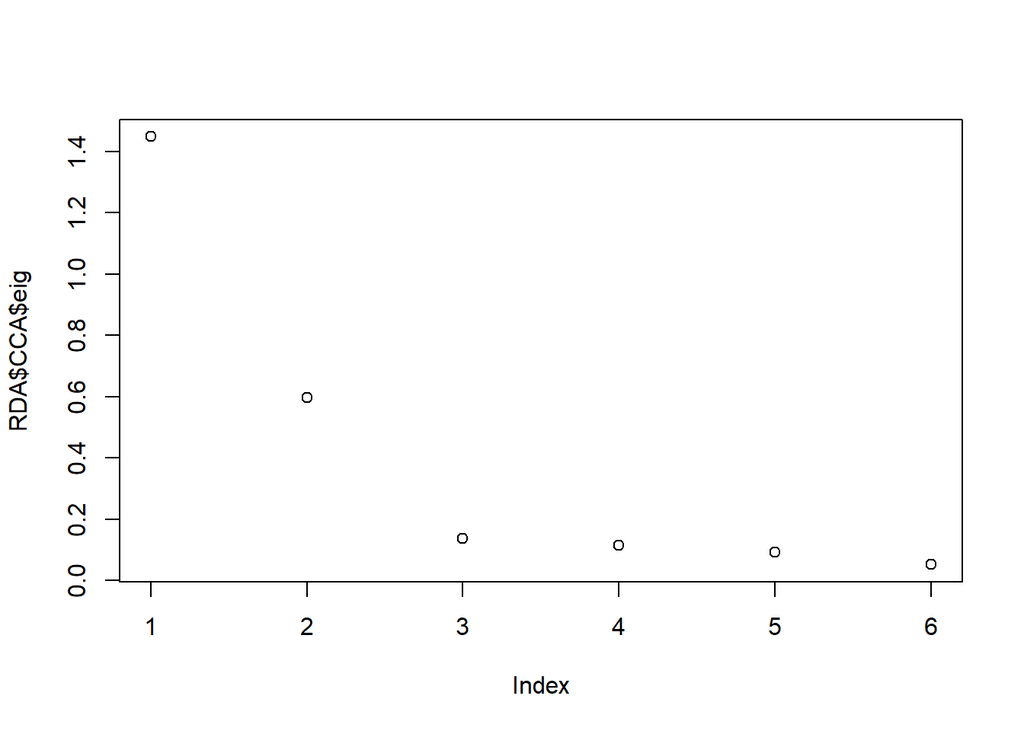

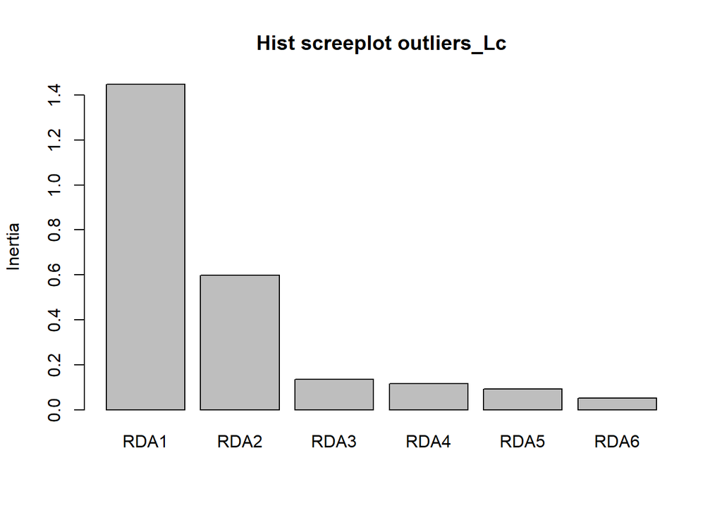

```
##      RDA1      RDA2      RDA3      RDA4      RDA5      RDA6
## 59.299725 24.467288  5.571946  4.712949  3.804574  2.143519
```

```r
for(x in 1: length(list_RDA_V2)){
  RDA <- get(list_RDA_V2[x])
  name <- c("all","random_SNPs","RDA_random_same_AF","outliers_Lc","Outliers_Mc","CG_set","random_AF_V2","all_outliers")
  #screeplot
plot(RDA$CCA$eig, option="screeplot")

#in hist
screeplot_RDA <- screeplot(RDA,main = paste0("Hist screeplot ",name[x]))

#explained variance along each RDA axis
explain_variance <-RDA$CCA$eig*100/sum(RDA$CCA$eig)

assign(paste0("explain_variance",name[x]),explain_variance)

  print(get(paste0("explain_variance",name[x])))
  #save
#pdf(paste0("C:/Users/tfrancisco/Documents/Thesis/Results/species/taxus/Genomic_offset/RDA/figures/screeplot/Screeplot_RDA_",name[x],".pdf"));screeplot(RDA,main = paste0("Hist screeplot ",name[x]));dev.off()
}
```

As can be seen, the first two RDA axes appear to explain most of the genetic variation of outliers across all sets. We will use these two axes in the further analysis of each set.

We can also plot the loci and climatic variables in the RDA space to visualise their relationships:

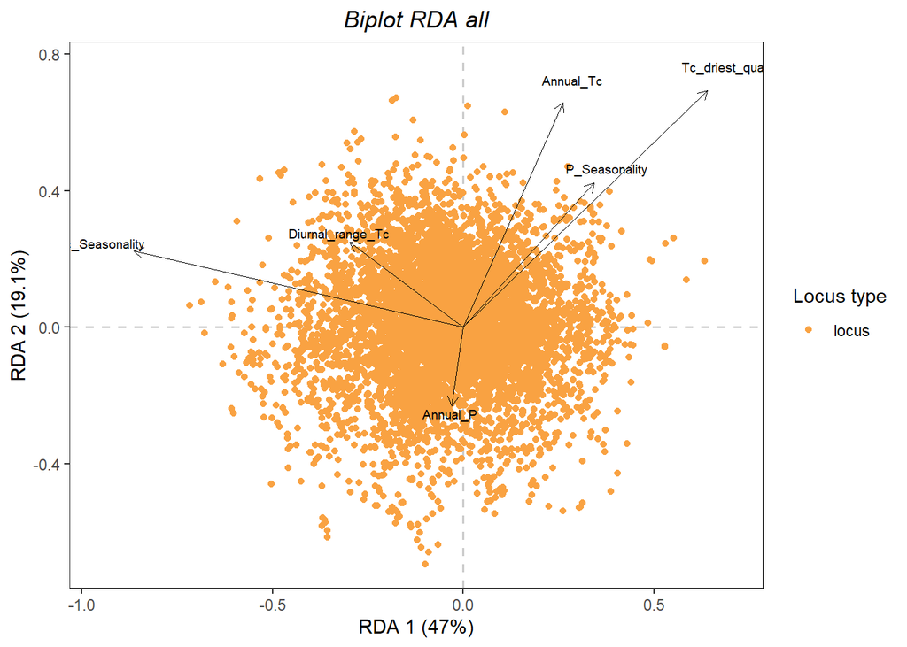

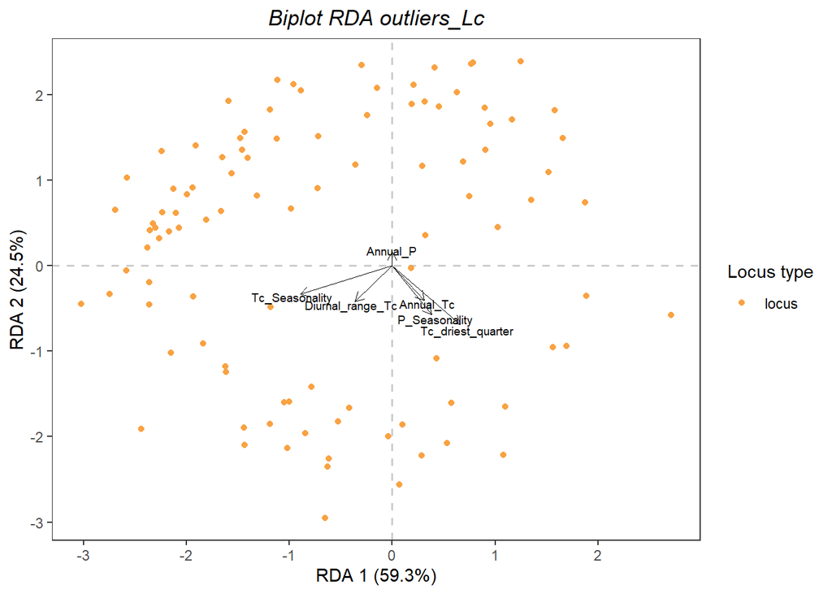

```r
for(x in 1:length(list_RDA_V2)){

  RDA <- get(list_RDA_V2[x])
  name <- c("all","random_SNPs","RDA_random_same_AF","outliers_Lc","Outliers_Mc","CG_set","random_AF_V2","all_outliers")

  score_loci <- as.data.frame(scores(RDA, choices=c(1:2), display="species", scaling="none"))
score_climatic_var <- as.data.frame(scores(RDA, choices=c(1:2), display="bp"))
explained_variance_round <- round(RDA$CCA$eig*100/sum(RDA$CCA$eig),digits=1)

#Biplot with SNPs and climatic variables along the two first RDA axis.
 biplot_outliers_RDA<- ggplot() +
  geom_hline(yintercept=0, linetype="dashed", color = gray(.80), size=0.6) +
  geom_vline(xintercept=0, linetype="dashed", color = gray(.80), size=0.6) +
  geom_point(data = score_loci, aes(x=RDA1*15, y=RDA2*15,color="locus"), size = 1.4) +
  geom_segment(data = score_climatic_var, aes(xend=RDA1, yend=RDA2, x=0, y=0), colour="black", size=0.15, linetype=1, arrow=arrow(length = unit(0.02, "npc"))) +
  geom_text(data = score_climatic_var, aes(x=1.1*RDA1, y=1.1*RDA2, label = row.names(score_climatic_var)), size = 2.5) +
  xlab(paste0("RDA 1 (",explained_variance_round[1],"%)")) +
  ylab(paste0("RDA 2 (",explained_variance_round[2],"%)")) +
   ggtitle(paste0("Biplot RDA ",name[x])) +
  guides(color=guide_legend(title="Locus type")) +
  scale_color_manual(values ="#F9A242FF") +
  theme_bw(base_size = 11) +
  theme(legend.position="right", panel.grid = element_blank(), strip.text = element_text(size=11),plot.title = element_text(hjust = 0.5,color = "Black",face="italic"))

 print(biplot_outliers_RDA)

 #save plots

#pdf(paste0("C:/Users/tfrancisco/Documents/Thesis/Results/species/taxus/Genomic_offset/RDA/figures/biplot/biplot_outliers_RDA_",name[x],".pdf"));print(biplot_outliers_RDA);dev.off()
}
```

Along the first axis, we observe a pattern of continentality/elevation, with colder temperatures, greater temperature seasonality and a higher diurnal temperature range on the left, which is associated with continental or high-altitude regions. On the right, there are outliers associated with higher temperatures, particularly during the driest quarter, as well as increased precipitation seasonality. These are linked to less continental or lower-altitude areas. For the MC set, the pattern is similar but reversed along the first RDA axis.

We can plot the populations in this space to see if their distribution follows the expected climatic pattern. Here, the population positions represent observed values rather than predicted ones, as in other studies.

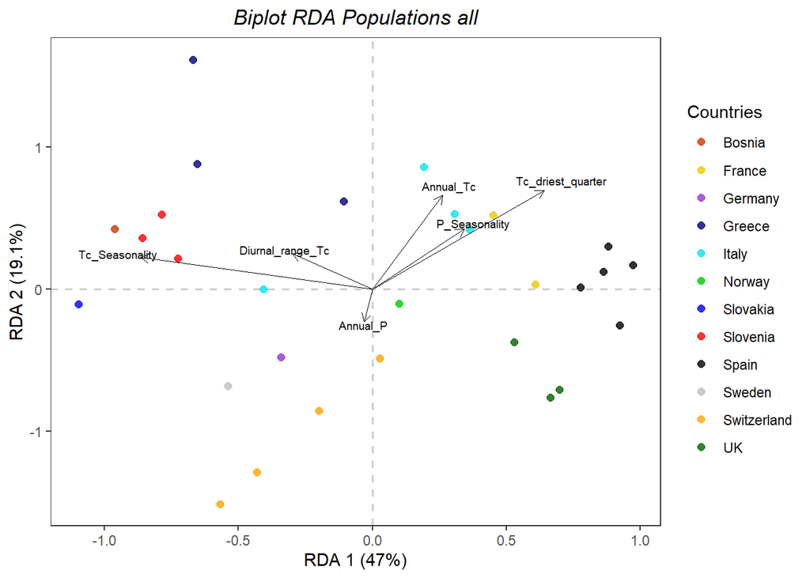

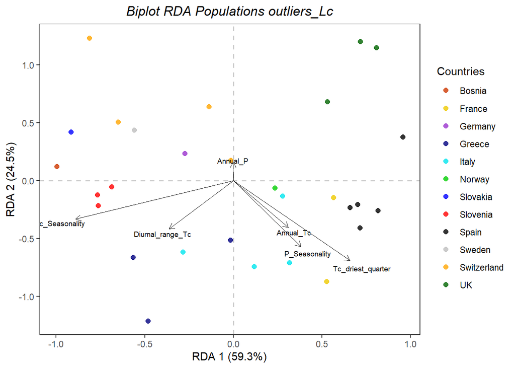

```r
for(x in 1:length(list_RDA_V2)){
  RDA <- get(list_RDA_V2[x])
  name <- c("all","random_SNPs","RDA_random_same_AF","outliers_Lc","Outliers_Mc","CG_set","random_AF_V2","all_outliers")

  #score along the 2 first RDA axis
score_climatic_var <- as.data.frame(scores(RDA, choices=c(1:2), display="bp"))
#Score_population <- data.frame(RDA$CCA$u[,c(1,2)]) #predicted population scores
observed_scores_populations <- as.data.frame(scores(RDA,choices=c(1,2), display = "sites",scaling="none"))

#explained variance
explained_variance_round <- round(RDA$CCA$eig*100/sum(RDA$CCA$eig),digits=1)

#merge for country info
Score_population_bis <- rownames_to_column(observed_scores_populations,"Population")
score_with_country_info <- merge(Score_population_bis,meta_data_pop_order[,c(1,2)],"Population")
score_with_country_info$Country <- as.factor(score_with_country_info$Country)


group_palette <- c("Bosnia"="orangered3", "France"="gold2","Germany"= "darkorchid3", "Greece"="navyblue", "Italy"="turquoise2", "Norway"="green3", "Slovakia"="blue", "Slovenia"="red", "Spain"="black", "Sweden"="gray", "Switzerland"="orange", "UK"="darkgreen")


##Biplot with populations and climatic variables along the 2 first RDA axis
biplot_populations <- ggplot() +
  geom_hline(yintercept = 0, linetype = "dashed", color = gray(0.80), size = 0.6) +
  geom_vline(xintercept = 0, linetype = "dashed", color = gray(0.80), size = 0.6) +
  geom_point(data = score_with_country_info, aes(x = RDA1 * 3, y = RDA2 * 3, colour = Country), size = 2, alpha = 0.8) +
  geom_segment(data = score_climatic_var, aes(xend = RDA1, yend = RDA2, x = 0, y = 0), colour = "black", size = 0.15, linetype = 1, arrow = arrow(length = unit(0.02, "npc"))) +
  geom_text(data = score_climatic_var, aes(x=1.1*RDA1, y=1.1*RDA2, label = row.names(score_climatic_var)), size = 2.5)+
  xlab(paste0("RDA 1 (",explained_variance_round[1],"%)")) +
  ylab(paste0("RDA 2 (",explained_variance_round[2],"%)")) +
  ggtitle(paste0("Biplot RDA Populations ",name[x])) +
  scale_color_manual(name = "Countries", values = group_palette, labels = levels(score_with_country_info$Country)) +
  theme_bw(base_size = 11) +
  theme(legend.position="right", panel.grid = element_blank(), strip.text = element_text(size=11),plot.title = element_text(hjust = 0.5,color = "Black",face="italic"))+
  labs(color = "Country")

 print(biplot_populations)

#save plots

#pdf(paste0("C:/Users/tfrancisco/Documents/Thesis/Results/species/taxus/Genomic_offset/RDA/figures/biplot/biplot_population_RDA_",name[x],".pdf"));print(biplot_populations);dev.off()
}
```

As before, we observe that the SNP pattern aligns here: more continental or high-altitude populations are located on the left, with the opposite pattern evident for the LC set on the right. Similarly, the pattern along the first RDA axis is reversed for the MC outlier set, though the information remains consistent.

# 4 Interpolate/extrapolate the GEA relationship to space and time to calculate the genomic composition

We can now calculate the predicted genomic composition for past, present and future climates. Please note that, unlike in the adaptive_index function, climatic values must be scaled prior to using this function. These results will then be used to calculate the GDI index and genomic offset.

```r
list_rda <- c("RDA_all","RDA_random","RDA_random_same_AF","RDA_outliers_LC","RDA_outliers_MC","RDA_CG","RDA_random_AF_V2","RDA_all_outliers")
#list_clim <- c("clim_df_past_scale","clim_df_present_scale","clim_df_future_scale")
list_period <- c("past","present","future")
list_set <- c("all","random","random_same_AF","LC","MC","CG","random_AF_V2","all_outliers")

K=2 #number of rda axes retained

for(i in 1: length(list_rda)){

  rda_model <- get(list_rda[i])
  set <- list_set[i]

  for(x in 1: length(list_period)){

  name <- list_period[x]

  if(name == "future"){

  for(a in 1:length(list_models_clim)){

  models_clim <- list_models_clim[a]
  clim <- get(paste0("clim_df_",name,"_scale_",models_clim))
  predictions <- data.frame(Population=meta_data_pop_order$Population,predict(rda_model,clim, type = "lc", rank = K, scaling = "none"))
  assign(paste0("adaptive_values_",set,"_",name,"_",models_clim),predictions)
  }

  }else{
    clim <- get(paste0("clim_df_",name,"_scale"))
  #model
  predictions <- data.frame(Population=meta_data_pop_order$Population,predict(rda_model,clim, type = "lc", rank = K, scaling = "none"))

  assign(paste0("adaptive_values_",set,"_",name),predictions)
  }
  }
}
```

# 5 Genomic discrepancy index (GDI)

The GDI is an index that calculates the difference between the predicted and observed genomic compositions. This enables us to identify populations that differ more from what would be expected based on local adaptation relationships. This suggests that these populations may have a lower degree of local adaptation, or that there may be a non-linear relationship (e.g. conditional neutrality), or that the SNPs used may not fully inform us about local adaptation that could arise due to the absence of local adaptation.

We applied the same method used for genomic offset to calculate this: measuring the distance between two genomic compositions, here, the observed and predicted values at the time of establishment (1901–1950, referred to as ‘past’).

## 5.1 Calculation

```r
genomic_discrepancy_index <- function(RDA, K, observed_score, predicted_score,meta_data){
# Weights based on axis eigen values
  weights <- RDA$CCA$eig/sum(RDA$CCA$eig)

  # Weighing the current and future adaptive indices based on the eigen values of the associated axes
  Proj_offset_observed <- as.data.frame(do.call(cbind, lapply(1:K, function(x) observed_score[,x]*weights[x])))

  predicted_score_df <- predicted_score[,-1]
  Proj_offset_predicted <- as.data.frame(do.call(cbind, lapply(1:K, function(x) predicted_score_df[,x]*weights[x])))


  #Now we want to calculate the distance between present and future for each RDA axis before doing it for both axis simultaneously
  Proj_offset <- list()
  for(i in 1:K){
  Proj_offset[[i]] <- abs(Proj_offset_observed[[i]] - Proj_offset_predicted[[i]])
      names(Proj_offset)[i] <- paste0("RDA", as.character(i))
  }

  # Predict a global genetic offset, incorporating the K first axes weighted by their eigen values
  ras <- Proj_offset[[1]] #we reused the format of the previous distance per RDA axis
  ras[!is.na(ras)] <- unlist(lapply(1:nrow(Proj_offset_observed), function(x) dist(rbind(Proj_offset_observed[x,], Proj_offset_predicted[x,]), method = "euclidean"))) #calculation of the euclidean distance on the non Na values of the previous distance -> that why we used the format of the previous distance, to be sure to only select the rows without Nas because they are not deal by euclidean distance,
  #the euclidean distance is still calculated on the weighted data (not the previous distance but on the genomic composition weighted)
  names(ras) <- "GDI"
  Proj_offset_global <- ras



  # Return prediction of genetic offset for each RDA axis and a global genetic offset for each population
  return(list(Population=meta_data$Population,Proj_offset = Proj_offset, Proj_offset_global = Proj_offset_global, weights = weights[1:K]))
}
```

```r
list_rda <- c("RDA_all","RDA_random","RDA_random_same_AF","RDA_outliers_LC","RDA_outliers_MC","RDA_CG","RDA_random_AF_V2","RDA_all_outliers")
list_predicted_adaptive_values <- c("adaptive_values_all_past","adaptive_values_random_past","adaptive_values_random_same_AF_past","adaptive_values_LC_past","adaptive_values_MC_past","adaptive_values_CG_past","adaptive_values_random_AF_V2_past","adaptive_values_all_outliers_past")

for(x in 1: length(list_rda)){

  rda <- get(list_rda[x])
  observed_values <- scores(rda, display = "sites",scaling="none")
  predicted_values <- data.frame(get(list_predicted_adaptive_values[x]))
  set <- list_set[x]

  calculated_GDI <- genomic_discrepancy_index(rda,K,observed_values,predicted_values,meta_data_pop_order)

  genomic_offset_df<- data.frame(Population=unlist(calculated_GDI$Population),Genomic_offset_random=unlist(calculated_GDI$Proj_offset_global))

 colnames(genomic_offset_df) <- c("Population",paste0("values_",set))

  assign(paste0("GDI_index_",set),genomic_offset_df)
}
```

We can save the values of GDI.

Compare the GDI with the residuals output by the residual function. The residual function provides a residual for each SNP in a population, so we need to summarise this information.

```r
res <- residuals(RDA_random_same_AF)

res_df <- as.data.frame(res)
#change residual value per SNP to numeric
res_df_numeric <- res_df %>%
  dplyr::mutate(across(everything(), as.numeric))

#add population info
res_df_numeric$Population <- row.names(res_df_numeric)

#calculate the mean residual across SNPs for each population
res_df_with_mean <- res_df_numeric %>%
  mutate(row_mean = rowMeans(dplyr::select(., where(is.numeric)), na.rm = TRUE))

#save the mean value of residual for each pop
res_df_with_mean_final <- data.frame(Population=row.names(res_df_numeric),residual=res_df_with_mean[,c(102)])

#load GDI value
load("C:/Users/tfrancisco/Documents/Thesis/Results/species/taxus/GDI/RDA/data/GDI_index_random_same_AF.Rdata")

#calculate correlation
cor(res_df_with_mean_final$residual,GDI_index_random_same_AF$values_random_same_AF)
```

```
## [1] 0.3155338
```

### 5.1.1 Relative GDI

Not used in this study.

```r
genomic_discrepancy_index <- function(RDA, K, observed_score, predicted_score, meta_data) {
  # Weights based on axis eigenvalues
  weights <- RDA$CCA$eig / sum(RDA$CCA$eig)

  # Weighted observed and predicted scores
  Proj_offset_observed <- as.data.frame(do.call(cbind, lapply(1:K, function(x) observed_score[,x] * weights[x])))
  predicted_score_df <- predicted_score[,-1]
  Proj_offset_predicted <- as.data.frame(do.call(cbind, lapply(1:K, function(x) predicted_score_df[,x] * weights[x])))

  # Calculate the absolute differences for each axis
  Proj_offset <- list()
  for (i in 1:K) {
    Proj_offset[[i]] <- abs(Proj_offset_observed[[i]] - Proj_offset_predicted[[i]])
    names(Proj_offset)[i] <- paste0("RDA", as.character(i))
  }

  # Calculate the global GDI using Euclidean distance across all axes
  Proj_offset_global <- unlist(lapply(1:nrow(Proj_offset_observed), function(x) {
    dist(rbind(Proj_offset_observed[x,], Proj_offset_predicted[x,]), method = "euclidean")
  }))
  names(Proj_offset_global) <- "GDI"

  # Calculate the relative index as a Euclidean distance of relative differences
  relative_change <- unlist(lapply(1:nrow(Proj_offset_observed), function(x) {
    # Extract the observed and predicted scores for this row as numeric vectors
    observed_row <- as.numeric(Proj_offset_observed[x, ])
    predicted_row <- as.numeric(Proj_offset_predicted[x, ])

    # Calculate relative differences for all axes
    relative_diff <- (predicted_row - observed_row) / observed_row
    relative_diff[is.nan(relative_diff) | is.infinite(relative_diff)] <- 0  # Handle division by zero or NA

    # Compute Euclidean distance of relative differences
    dist(rbind(rep(0, K), relative_diff), method = "euclidean")
  }))
  names(relative_change) <- "Relative_Index"

  # Return results
  return(list(
    Population = meta_data$Population,
    Proj_offset = Proj_offset,
    Proj_offset_global = Proj_offset_global,
    Relative_change = relative_change,
    weights = weights[1:K]
  ))
}
```

```r
list_rda <- c("RDA_all", "RDA_random", "RDA_random_same_AF", "RDA_outliers_LC", "RDA_outliers_MC", "RDA_CG")
list_predicted_adaptive_values <- c("adaptive_values_all_past", "adaptive_values_random_past", "adaptive_values_random_same_AF_past", "adaptive_values_LC_past", "adaptive_values_MC_past", "adaptive_values_CG_past")

for (x in 1:length(list_rda)) {
  rda <- get(list_rda[x])
  observed_values <- scores(rda, display = "sites", scaling = "none")
  predicted_values <- data.frame(get(list_predicted_adaptive_values[x]))
  set <- list_set[x]

  # Calculate GDI and Relative Change using the updated function
  calculated_GDI <- genomic_discrepancy_index(rda, K, observed_values, predicted_values, meta_data_pop_order)

  # Create a dataframe for GDI and combined relative index values
  genomic_offset_df <- data.frame(
    Population = unlist(calculated_GDI$Population),
    Genomic_offset = unlist(calculated_GDI$Proj_offset_global),
    Relative_Index = unlist(calculated_GDI$Relative_change)  # Add the combined relative index
  )

  # Rename columns to be more informative
  colnames(genomic_offset_df) <- c("Population", paste0("values_", set), paste0("Relative_Index_", set))

  # Assign the dataframe to a new variable with a dynamic name
  assign(paste0("GDI_index_bis_", set), genomic_offset_df)
}
```

## 5.2 Plot the GDI values

We can plot the GDI values for each population. As before, we can use the ‘cut_interval’ function (never use ‘cut_number’!) to rescale the values so that they match the colour scale used for other genomic offsets, such as GF.

[figure not shown]

```r
shapefile <- st_read("C:/Users/tfrancisco/Documents/Thesis/Data/Species/Taxus_baccata/shapefiles/Taxus_baccata_plg_clip.shp")

list_period <- c("present","future")
list_set <- c("all","random","random_same_AF","LC","MC","CG","random_AF_V2","all_outliers")

# Loop to find the global min and max values across all data frames to cut the values and be able to compare the values across model.
#for(set in list_set){
#  GDI_df <- get(paste0("GDI_index_",set))
#  global_min <- min(global_min, min(GDI_df[,2], na.rm = TRUE))
#  global_max <- max(global_max, max(GDI_df[,2], na.rm = TRUE))
#}
  for(x in 1: length(list_set)){

    set <- list_set[x]
    GDI_df <- get(paste0("GDI_index_",set))

     #first, we need to add the coordinates
GDI_coord <- merge(GDI_df,meta_data_pop_order[,c(2,4,5)],"Population")

#transform longitude and latitude to numeric variables
GDI_coord <- GDI_coord %>% mutate(Longitude=as.numeric(Longitude),Latitude=as.numeric(Latitude))


colors <- c( "darkgreen", "#FDF7B3","#FC4E2A","#BD0026","darkorchid4")
colors <- c("#005000","#85B22C","#FFFFBF","#F76D5E","#E51932")

#background map
admin <- ne_countries(scale = "medium", returnclass = "sf")

plot <- ggplot(data = GDI_coord) +
  geom_sf(data = admin, fill = gray(0.92), size = 0) +
  geom_sf(data = shapefile, fill = "lightgrey", color = "black", size = 0.2) +  # Adding shapefile
  geom_point(aes(x = Longitude, y = Latitude, fill = cut_interval(GDI_coord[,2], n = 5)), shape = 21,size=3, color = "black") +
  #geom_point(aes(x = Longitude, y = Latitude, fill = cut(GDI_coord[,2], breaks=seq(global_min, global_max, length.out = 6), include.lowest = T)), shape = 21,size=3, color = "black") + #if we want to class with the same values the 4 models to compare color
  scale_fill_manual(
    values = colors,
    labels = c("0","","","","1"),
    drop = FALSE,na.translate = FALSE)+  # Ensure all levels are shown in the legend
  geom_sf(data = admin, fill = NA, size = 0.1) +
  coord_sf(xlim = c(-10, 30), ylim = c(35, 62), expand = FALSE) +
  xlab("Longitude") + ylab("Latitude") +
  guides(fill = guide_legend(title = NULL)) +
  ggtitle(paste0("Adaptive genomic disruption across populations ",set)) +
  annotation_scale(location = "br", width_hint = 0.3) + # Scale bar at bottom left
  annotation_north_arrow(location = "tl", which_north = "true",
                         pad_x = unit(-0.2, "cm"), pad_y = unit(0.08, "cm"),
                         style = north_arrow_fancy_orienteering) + # Compass rose
  theme_bw(base_size = 11) +
  theme(legend.position="right", panel.grid = element_blank(), strip.text = element_text(size=11),plot.title = element_text(hjust = 0.5,color = "Black",face="italic"))

print(plot)

#save
     pdf(paste0("C:/Users/tfrancisco/Documents/Thesis/Results/species/taxus/GDI/RDA/figures/GDI_across_populations ",set,"_newcolors.pdf"));print(plot);dev.off()
}
```

```r
write.csv(GDI_index_random_same_AF,file="C:/Users/tfrancisco/Documents/Thesis/Results/species/taxus/GDI/RDA/predictions/GDI_index_random_same_AF.csv")
```

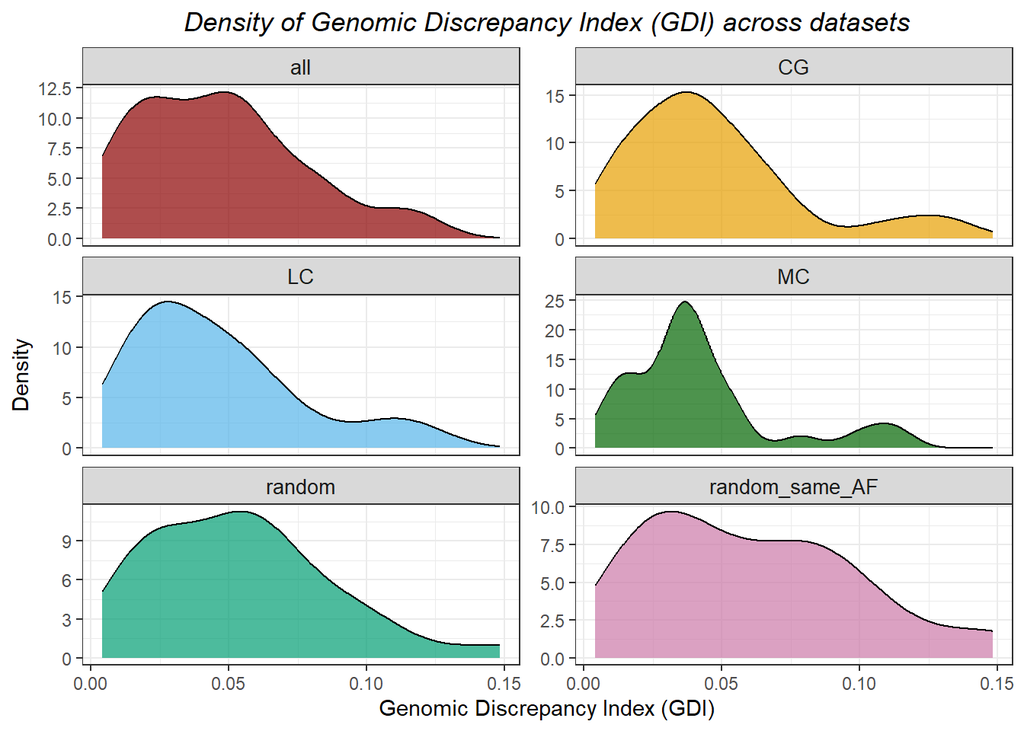

```r
list_set <- c("all","random","random_same_AF","LC","MC","CG")

# Combine all GDI values into one dataframe
combined_data <- data.frame()

for (set in list_set) {
  GDI_df <- get(paste0("GDI_index_", set))
  colnames(GDI_df)[2] <- "GDI"  # Ensure second column is named GDI
  GDI_df$Set <- set
  combined_data <- rbind(combined_data, GDI_df[, c("GDI", "Set")])
}

# Density plot
density_plot <- ggplot(combined_data, aes(x = GDI, fill = Set)) +
  geom_density(alpha = 0.7, color = "black") +
  scale_fill_manual(values = c("darkred", "#E69F00", "#56B4E9", "darkgreen", "#009E73", "#CC79A7")) +
  #geom_vline(xintercept = 1, color = "red", linetype = "dashed", size = 1) +  # Optional threshold
  facet_wrap(~ Set, scales = "free_y", ncol = 2) +
  labs(
    title = "Density of Genomic Discrepancy Index (GDI) across datasets",
    x = "Genomic Discrepancy Index (GDI)",
    y = "Density"
  ) +
  theme_bw() +
  theme(
    plot.title = element_text(hjust = 0.5, face = "italic"),
    strip.text = element_text(size = 10),
    legend.position = "none"
  )

print(density_plot)
```

```r
# Save to PDF
pdf("C:/Users/tfrancisco/Documents/Thesis/Results/species/taxus/GDI/RDA/figures/GDI_density_faceted.pdf")
print(density_plot)
dev.off()
```

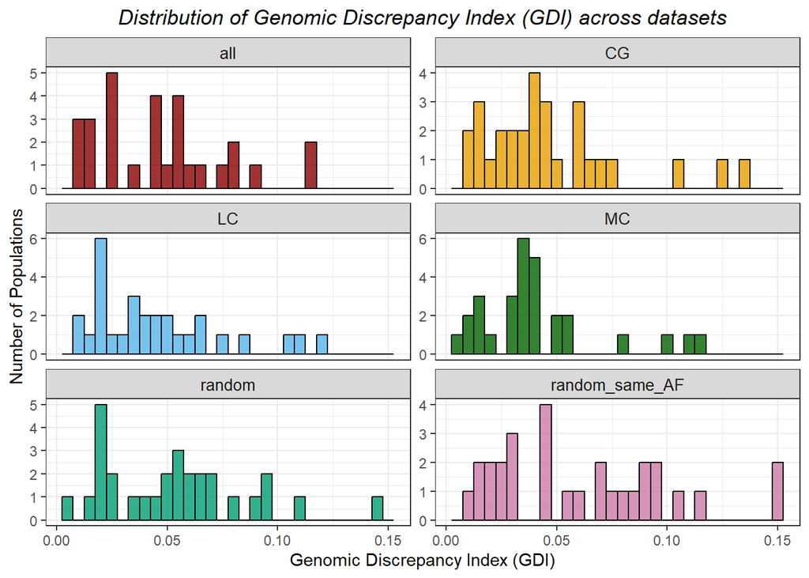

```r
list_set <- c("all","random","random_same_AF","LC","MC","CG")

# Combine all GDI values into one dataframe
combined_data <- data.frame()

for (set in list_set) {
  GDI_df <- get(paste0("GDI_index_", set))
  colnames(GDI_df)[2] <- "GDI"  # Ensure second column is named GDI
  GDI_df$Set <- set
  combined_data <- rbind(combined_data, GDI_df[, c("GDI", "Set")])
}

# Plot: histogram of GDI values, faceted by set
plot <- ggplot(combined_data, aes(x = GDI)) +
  geom_histogram(aes(fill = Set), binwidth = 0.005, color = "black", alpha = 0.8) +
  scale_fill_manual(values = c("darkred", "#E69F00", "#56B4E9", "darkgreen", "#009E73", "#CC79A7")) +
  #geom_vline(xintercept = 1, color = "red", linetype = "dashed", size = 1) +  # Adjust or remove if not relevant
  facet_wrap(~ Set, scales = "free_y", ncol = 2) +
  labs(
    title = "Distribution of Genomic Discrepancy Index (GDI) across datasets",
    x = "Genomic Discrepancy Index (GDI)",
    y = "Number of Populations"
  ) +
  theme_bw() +
  theme(
    plot.title = element_text(hjust = 0.5, face = "italic"),
    strip.text = element_text(size = 10),
    legend.position = "none"
  )

print(plot)
```

```r
# #Save
pdf("C:/Users/tfrancisco/Documents/Thesis/Results/species/taxus/GDI/RDA/figures/GDI_distribution_histogram_faceted.pdf")
print(plot)
dev.off()
```

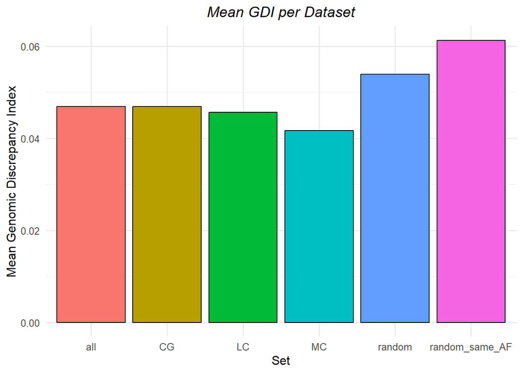

```r
# Prepare an empty data frame to collect means
mean_GDI_df <- data.frame(Set = character(), Mean_GDI = numeric(), stringsAsFactors = FALSE)

for (set in list_set) {
  GDI_df <- get(paste0("GDI_index_", set))
  colnames(GDI_df)[2] <- "GDI"

  mean_val <- mean(GDI_df$GDI, na.rm = TRUE)
  mean_GDI_df <- rbind(mean_GDI_df, data.frame(Set = set, Mean_GDI = mean_val))
}

# Plot
barplot <- ggplot(mean_GDI_df, aes(x = Set, y = Mean_GDI, fill = Set)) +
  geom_bar(stat = "identity", color = "black") +
  ylab("Mean Genomic Discrepancy Index") +
  xlab("Set") +
  ggtitle("Mean GDI per Dataset") +
  theme_minimal(base_size = 12) +
  theme(
    plot.title = element_text(hjust = 0.5, face = "italic"),
    legend.position = "none"
  )

print(barplot)
```

```r
# Save plot
ggsave(
  filename = "C:/Users/tfrancisco/Documents/Thesis/Results/species/taxus/GDI/RDA/figures/Mean_GDI_barplot_across_sets.pdf",
  plot = barplot, width = 8, height = 6
)
```

Example LC: Overall, an interesting pattern emerges, with higher GDI values observed in populations that appear to be isolated from others, such as those in Greece. However, this pattern is inconsistent, as high GDI values are not observed in isolated northern populations (e.g. Sweden and Norway). We can also compare GDI values across models and with respect to elevation.

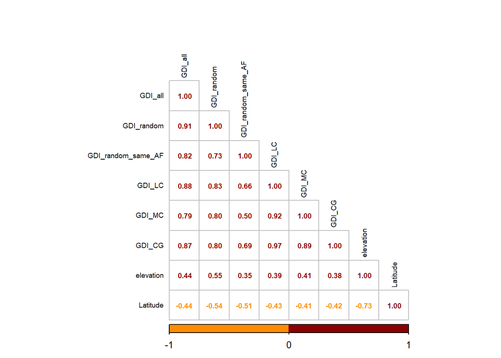

```r
#df GDI and elevation
df_GDI_cor <- data.frame(GDI_all=GDI_index_all$values_all,GDI_random=GDI_index_random$values_random,GDI_random_same_AF=GDI_index_random_same_AF$values_random_same_AF,GDI_LC=GDI_index_LC$values_LC,GDI_MC=GDI_index_MC$values_MC,GDI_CG=GDI_index_CG$values_CG,elevation=as.numeric(meta_data_pop_order$Elevation.DEM_90m.),Latitude=as.numeric(meta_data_pop_order$Latitude))

#correlation
correlation_GDI <- cor(df_GDI_cor)

corrplot(correlation_GDI, method = "number", addrect = 2, col = c("darkorange","darkred"), type = "lower", tl.col = "black", tl.cex = 0.6, number.cex = 0.6)
```

```r
pdf("C:/Users/tfrancisco/Documents/Thesis/Results/species/taxus/GDI/RDA/figures/comparison/correlation_GDI_values_RDA_taxus.pdf");corrplot(correlation_GDI, method = "number", addrect = 2, col = c("darkorange","darkred"), type = "lower", tl.col = "black", tl.cex = 0.6, number.cex = 0.6);dev.off()
```

# 6 Genomic offset

We adapted the function from Capblancq and Forester (2021) so that our analysis focuses solely on calculating the genomic offset for populations without interpolating or extrapolating across space.

## 6.1 Genomic offset with predicted genomic composition

### 6.1.1 Model

Due to the significant computational time required by the function used in Capblancq and Forester (2021) to calculate the genomic offset (GO) for all raster points, we modified the function to calculate the GO exclusively for our sampled points.

```r
genomic_offset_pop <- function(RDA, K, Past_score, Future_score,meta_data){
# Weights based on axis eigen values
  weights <- RDA$CCA$eig/sum(RDA$CCA$eig)

  # Weighing the current and future adaptive indices based on the eigen values of the associated axes
  Past_score_df <- Past_score[,-c(1)]
  Proj_offset_past <- as.data.frame(do.call(cbind, lapply(1:K, function(x) Past_score_df[,x]*weights[x])))
  Future_score_df <- Future_score[,-c(1)]
  Proj_offset_fut <- as.data.frame(do.call(cbind, lapply(1:K, function(x) Future_score_df[,x]*weights[x])))


  #Now we want to calculate the distance between present and future for each RDA axis before doing it for both axis simultaneously
  Proj_offset <- list()
  for(i in 1:K){
  Proj_offset[[i]] <- abs(Proj_offset_past[[i]] - Proj_offset_fut[[i]])
      names(Proj_offset)[i] <- paste0("RDA", as.character(i))
  }


  # Predict a global genetic offset, incorporating the K first axes weighted by their eigen values
  ras <- Proj_offset[[1]] #we reused the format of the previous distance per RDA axis
  ras[!is.na(ras)] <- unlist(lapply(1:nrow(Proj_offset_past), function(x) dist(rbind(Proj_offset_past[x,], Proj_offset_fut[x,]), method = "euclidean"))) #calculation of the euclidean distance on the non Na values of the previous distance -> that why we used the format of the previous distance, to be sure to only select the rows without Nas because they are not deal by euclidean distance,
  #the euclidean distance is still calculated on the weighted data (not the previous distance but on the genomic composition weighted)
  names(ras) <- "Global_offset"
  Proj_offset_global <- ras



  # Return prediction of genetic offset for each RDA axis and a global genetic offset for each population
  return(list(Population=meta_data$Population,Proj_offset = Proj_offset, Proj_offset_global = Proj_offset_global, weights = weights[1:K]))
}
```

We can run the GO function for all the set of genetic markers for present and future climate:

```r
list_RDA <- c("RDA_all","RDA_random", "RDA_random_same_AF", "RDA_outliers_LC", "RDA_outliers_MC", "RDA_CG","RDA_random_AF_V2","RDA_all_outliers")
list_past_score <- c("adaptive_values_all_past","adaptive_values_random_past", "adaptive_values_random_same_AF_past", "adaptive_values_LC_past", "adaptive_values_MC_past", "adaptive_values_CG_past","adaptive_values_random_AF_V2_past","adaptive_values_all_outliers_past")
list_present_score <- c("adaptive_values_all_present","adaptive_values_random_present", "adaptive_values_random_same_AF_present", "adaptive_values_LC_present", "adaptive_values_MC_present", "adaptive_values_CG_present","adaptive_values_random_AF_V2_present","adaptive_values_all_outliers_present")
#list_future_score <- c("adaptive_values_all_future","adaptive_values_random_future", "adaptive_values_random_same_AF_future", "adaptive_values_LC_future", "adaptive_values_MC_future", "adaptive_values_CG_future")
list_name_present <- c("all_present","random_present", "random_same_AF_present", "LC_present", "MC_present", "CG_present","random_AF_V2_present","all_outliers_present")
list_name_future <- c("all_future","random_future", "random_same_AF_future", "LC_future", "MC_future", "CG_future","random_AF_V2_future","all_outliers_future")

# Loop through each RDA model
for (i in 1:length(list_RDA)) {
  # Get the RDA model, past score, present score, and future score
  RDA <- get(list_RDA[i])
  adaptive_past_score <- get(list_past_score[i])
  present_score <- get(list_present_score[i])

  # Calculate genomic offset for the present scenario
  name_present <- list_name_present[i]
  Run_genomic_offset_pop_present <- genomic_offset_pop(RDA, 2, adaptive_past_score, present_score, meta_data_pop_order)

  # Create a data frame for the present scenario genomic offset
  genomic_offset_df_present <- data.frame(Population = unlist(Run_genomic_offset_pop_present$Population),
                                          Genomic_offset_random = unlist(Run_genomic_offset_pop_present$Proj_offset_global))

  # Order the data frame by population and rename columns
  Genomic_offset_Taxus_Adapcon_Gentree_RDA_present <- genomic_offset_df_present[order(genomic_offset_df_present$Population), ]
  colnames(Genomic_offset_Taxus_Adapcon_Gentree_RDA_present) <- c("Population", paste0("GO_", name_present))

  # Assign the present result to a new variable
  assign(paste0("Genomic_offset_Taxus_Adapcon_Gentree_RDA_", name_present), Genomic_offset_Taxus_Adapcon_Gentree_RDA_present)

  # Calculate genomic offset for the future scenario
  for (j in 1:length(list_models_clim)) {  # Loop through 5 future models

    name_clim <- list_models_clim[j]
    name_future <- paste0(list_name_future[i],"_", name_clim)
    future_score <- get(paste0("adaptive_values_",list_name_future[i],"_", name_clim))
  Run_genomic_offset_pop_future <- genomic_offset_pop(RDA, 2, adaptive_past_score, future_score, meta_data_pop_order)

  # Create a data frame for the future scenario genomic offset
  genomic_offset_df_future <- data.frame(Population = unlist(Run_genomic_offset_pop_future$Population),
                                         Genomic_offset_random = unlist(Run_genomic_offset_pop_future$Proj_offset_global))

  # Order the data frame by population and rename columns
  Genomic_offset_Taxus_Adapcon_Gentree_RDA_future <- genomic_offset_df_future[order(genomic_offset_df_future$Population), ]
  colnames(Genomic_offset_Taxus_Adapcon_Gentree_RDA_future) <- c("Population", paste0("GO_", name_future))

  # Assign the future result to a new variable
  assign(paste0("Genomic_offset_Taxus_Adapcon_Gentree_RDA_",name_future), Genomic_offset_Taxus_Adapcon_Gentree_RDA_future)
  }
}
```

We can save the genomic offset values for downstream analysis.

save present predictions for chapter 2 for the random set of SNPs

```r
save(GO_T_Adapcon_Gentree_RDA_random_same_AF_present,file="C:/Users/tfrancisco/Documents/Thesis/Results/species/taxus/Genomic_offset/RDA/predictions/GO_T_Adapcon_Gentree_RDA_random_same_AF_present.Rdata")

write.csv(GO_T_Adapcon_Gentree_RDA_random_same_AF_present,file="C:/Users/tfrancisco/Documents/Thesis/Results/species/taxus/Genomic_offset/RDA/predictions/GO_T_Adapcon_Gentree_RDA_random_same_AF_present.csv")
```

### 6.1.2 Comparison GO predictions across climatic models

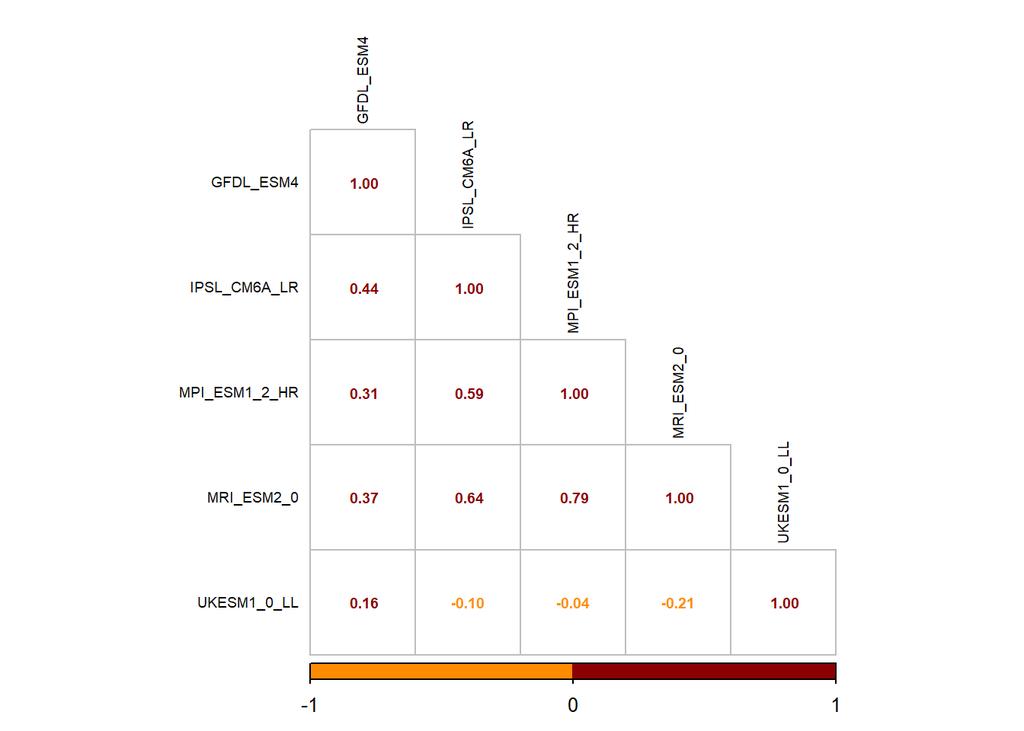

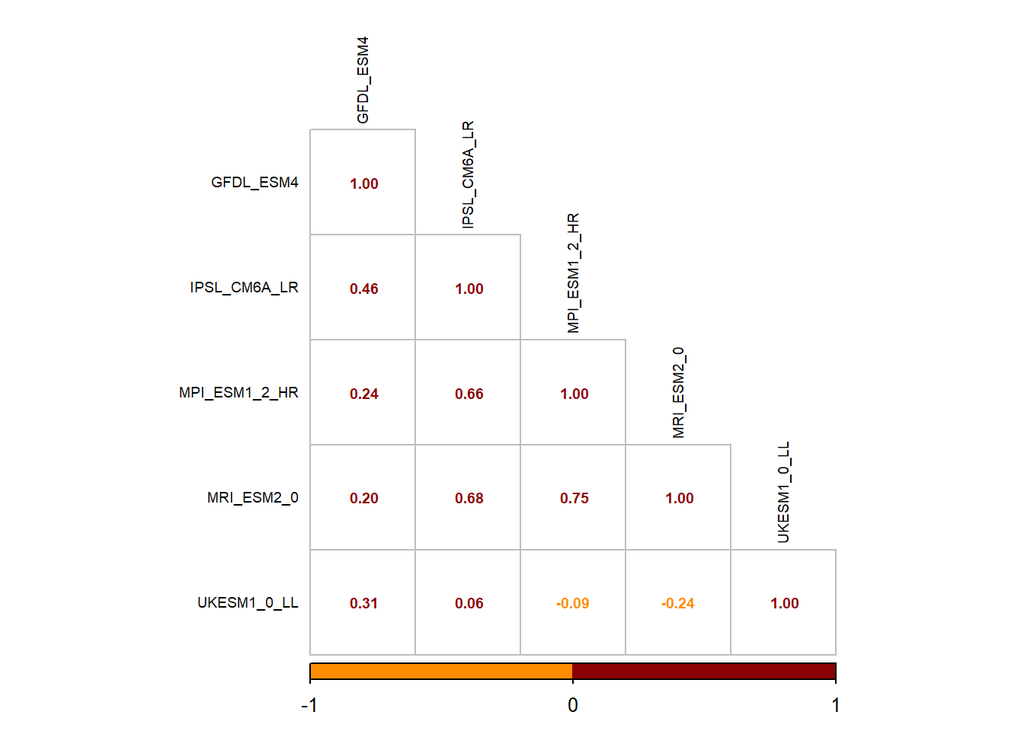

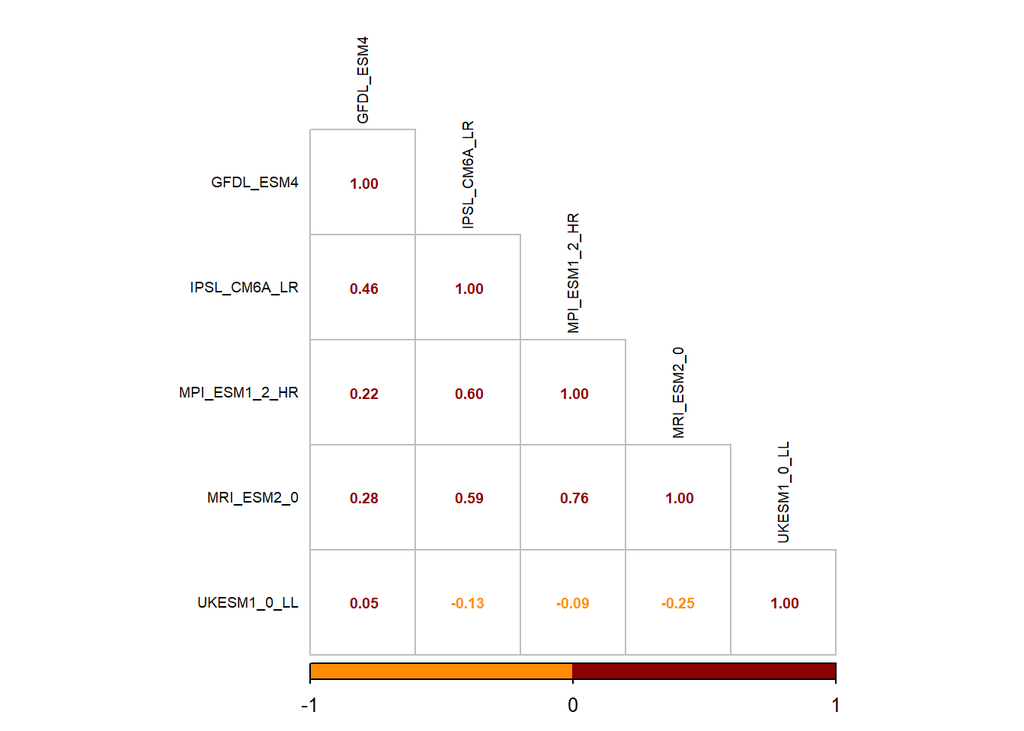

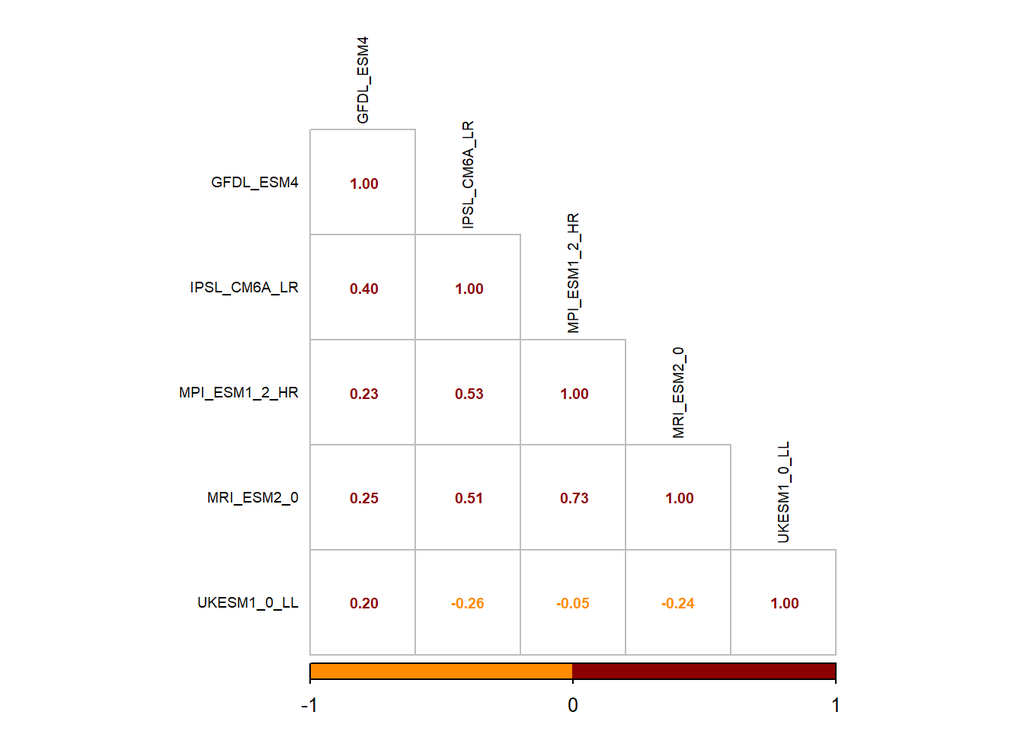

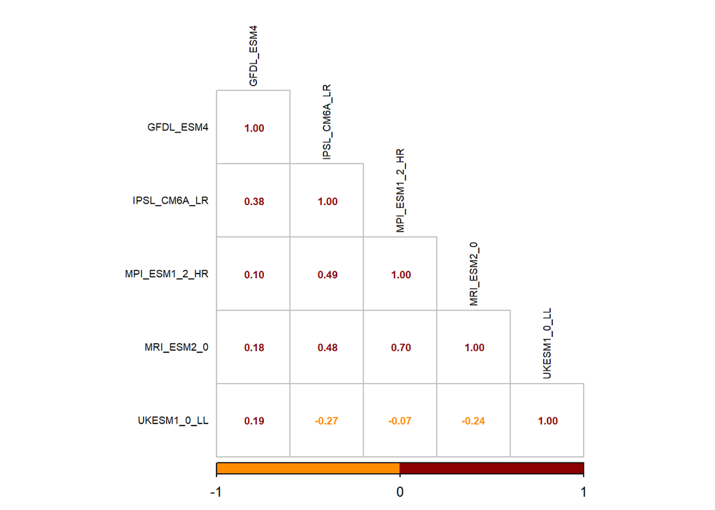

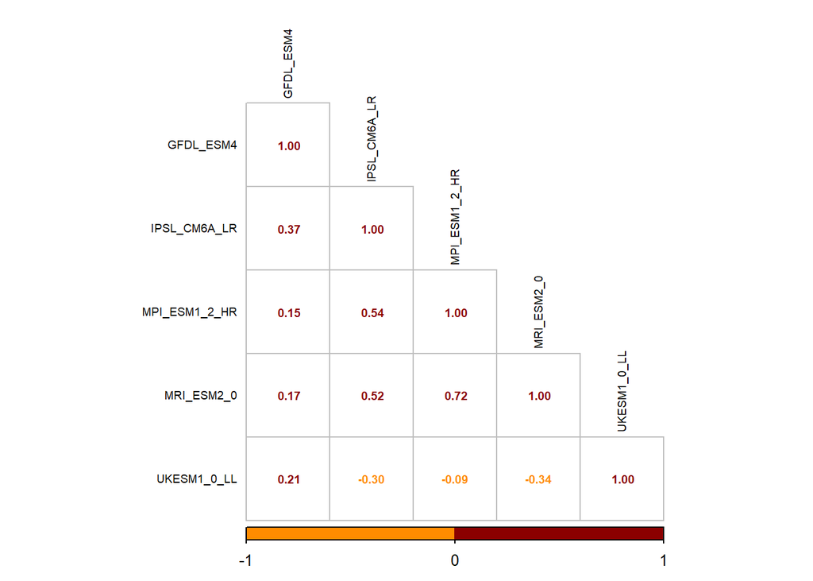

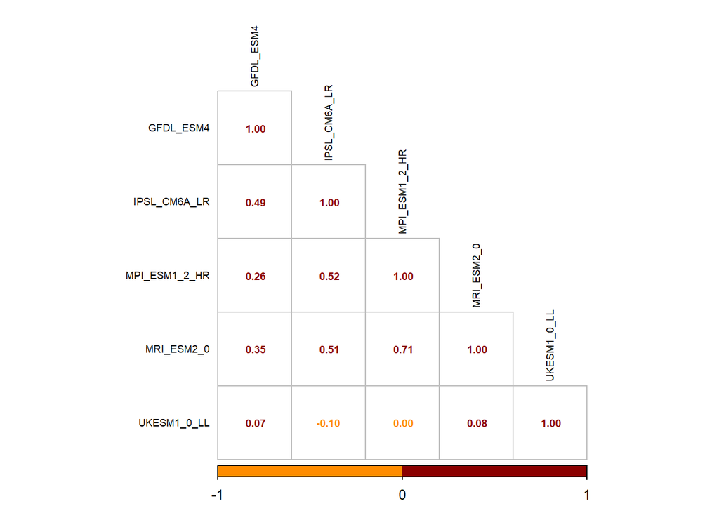

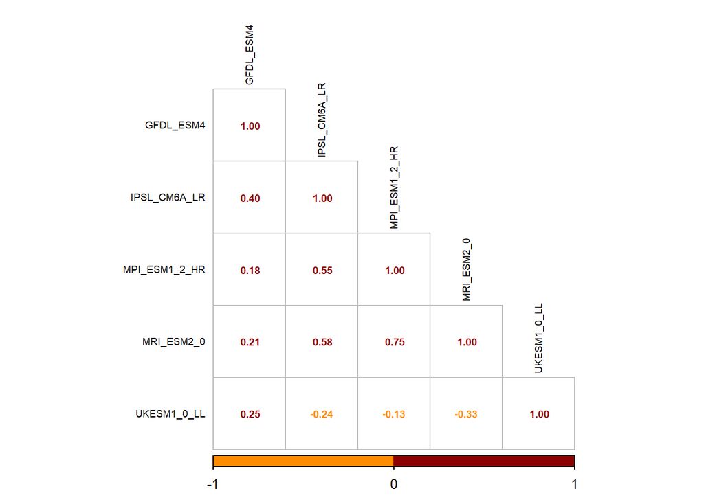

```r
list_set <- c("all","random","random_same_AF","LC","MC","CG","random_AF_V2","all_outliers")

for(x in 1:length(list_set)){

  set <- list_set[x]

 df_tot_GO_predictions_clim_models_future <- data.frame(Population=GO_T_Adapcon_Gentree_RDA_random_future_GFDL_ESM4[,1],GFDL_ESM4=get(paste0("GO_T_Adapcon_Gentree_RDA_",set,"_future_GFDL_ESM4"))[,2],IPSL_CM6A_LR=get(paste0("GO_T_Adapcon_Gentree_RDA_",set,"_future_IPSL_CM6A_LR"))[,2],MPI_ESM1_2_HR=get(paste0("GO_T_Adapcon_Gentree_RDA_",set,"_future_MPI_ESM1_2_HR"))[,2],MRI_ESM2_0=get(paste0("GO_T_Adapcon_Gentree_RDA_",set,"_future_MRI_ESM2_0"))[,2],UKESM1_0_LL=get(paste0("GO_T_Adapcon_Gentree_RDA_",set,"_future_UKESM1_0_LL"))[,2])#elevation=as.numeric(meta_data_pop_order$Elevation.DEM_90m.

correlation_future <- cor(df_tot_GO_predictions_clim_models_future[,-1])
corrplot(correlation_future, method = "number", addrect = 2, col = c("darkorange","darkred"), type = "lower", tl.col = "black", tl.cex = 0.6, number.cex = 0.6)

pdf(paste0("C:/Users/tfrancisco/Documents/Thesis/Results/species/taxus/Genomic_offset/RDA/figures/comparison/GCMs/correlation_future_predictions_GCMs_",set,".pdf"));corrplot(correlation_future, method = "number", addrect = 2, col = c("darkorange","darkred"), type = "lower", tl.col = "black", tl.cex = 0.6, number.cex = 0.6);dev.off()

}
```

```r
list_models_clim<- c("GFDL_ESM4","IPSL_CM6A_LR","MPI_ESM1_2_HR","MRI_ESM2_0","UKESM1_0_LL")

for(x in 1:length(list_set)){

  set <- list_set[x]
  all_GO <- data.frame()

 for(i in 1:length(list_models_clim)){

   model <- list_models_clim[i]
   GO_data <- get(paste0("Genomic_offset_Taxus_Adapcon_Gentree_RDA_", set, "_future_", model))
   colnames(GO_data) <- c("Population","GO")
   all_GO <- rbind(all_GO,GO_data)
 }

  mean_GO <- aggregate(GO ~ Population, data = all_GO, FUN = mean, na.rm = TRUE)

colnames(mean_GO) <- c("Population", "Mean_GO")  # Rename the columns for clarity

assign(paste0("GO_T_Adapcon_Gentree_RDA_", set, "_future_mean"),mean_GO)

#save
file_save<- get(paste0("GO_T_Adapcon_Gentree_RDA_", set, "_future_mean"))
  name <- paste0("GO_T_Adapcon_Gentree_RDA_", set, "_future_mean")
save(list = name,file=paste0("C:/Users/tfrancisco/Documents/Thesis/Results/species/taxus/Genomic_offset/RDA/data/",name,".Rdata"))
}
```

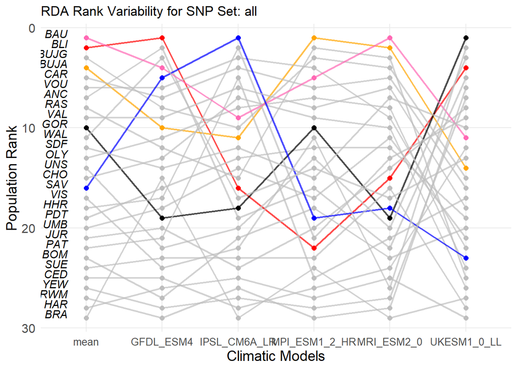

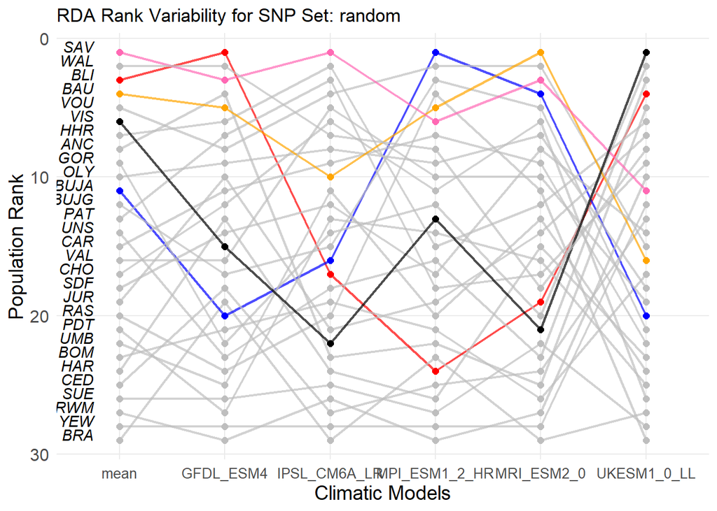

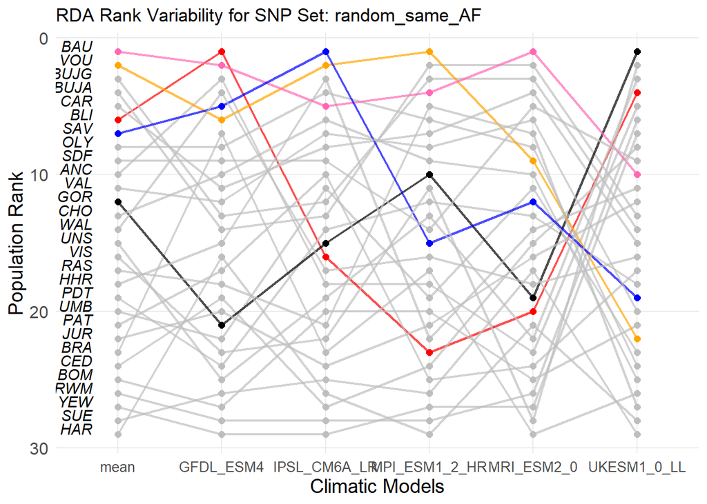

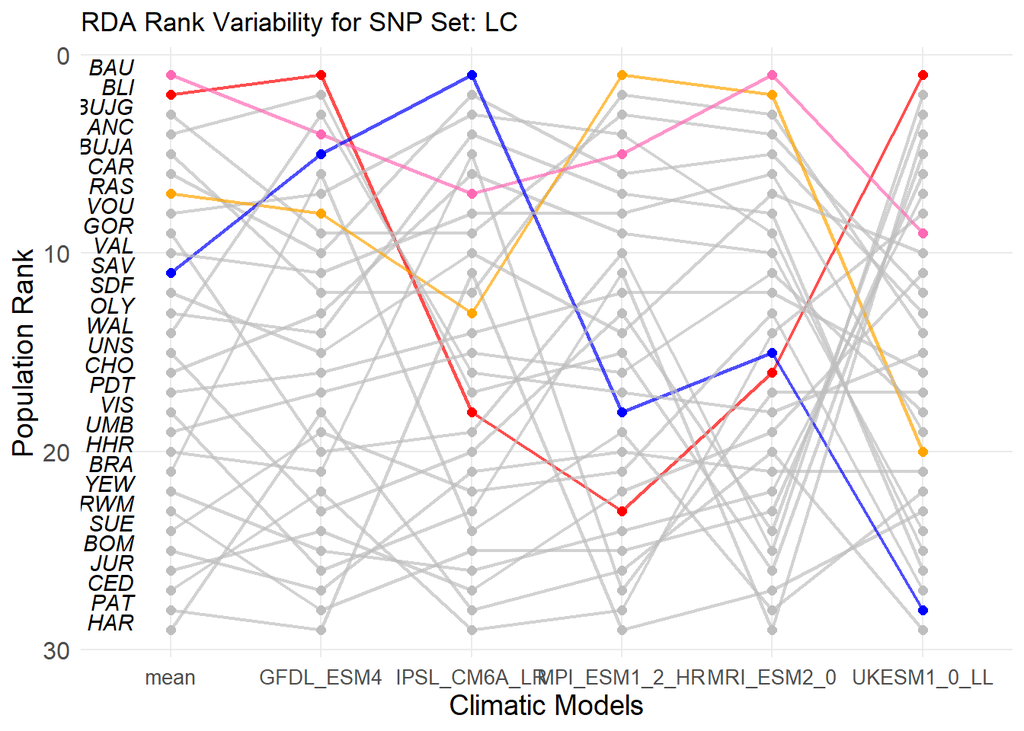

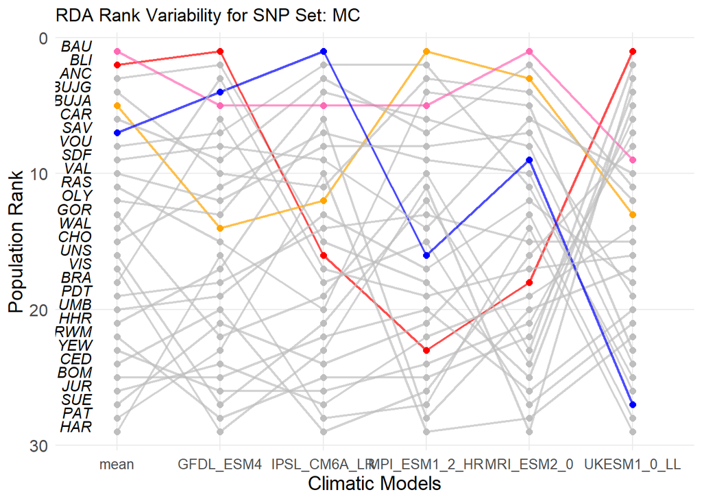

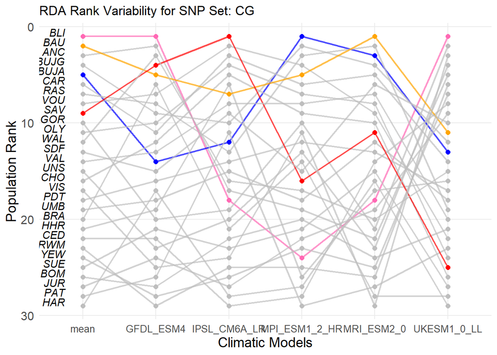

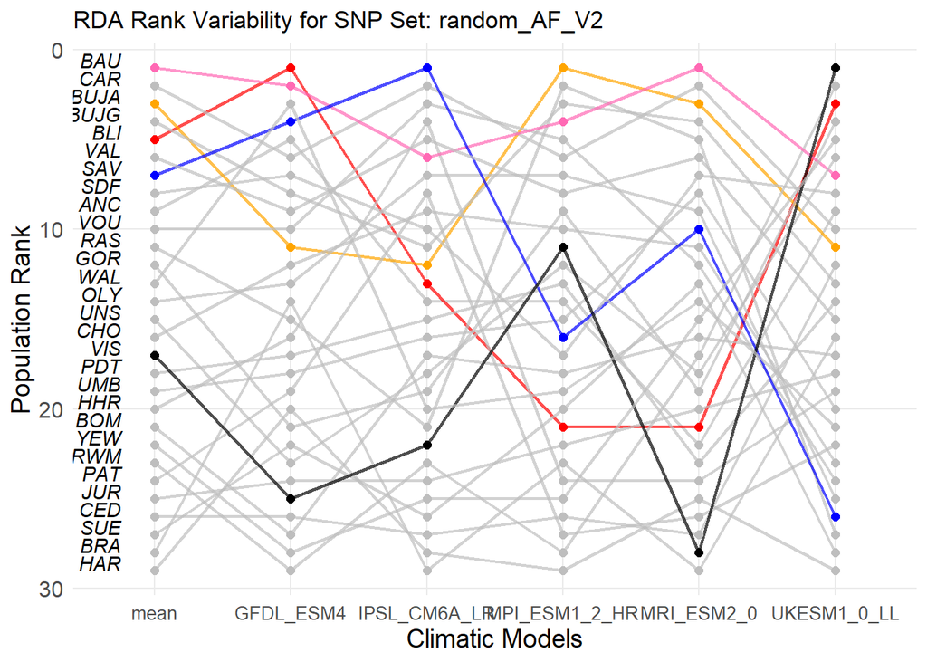

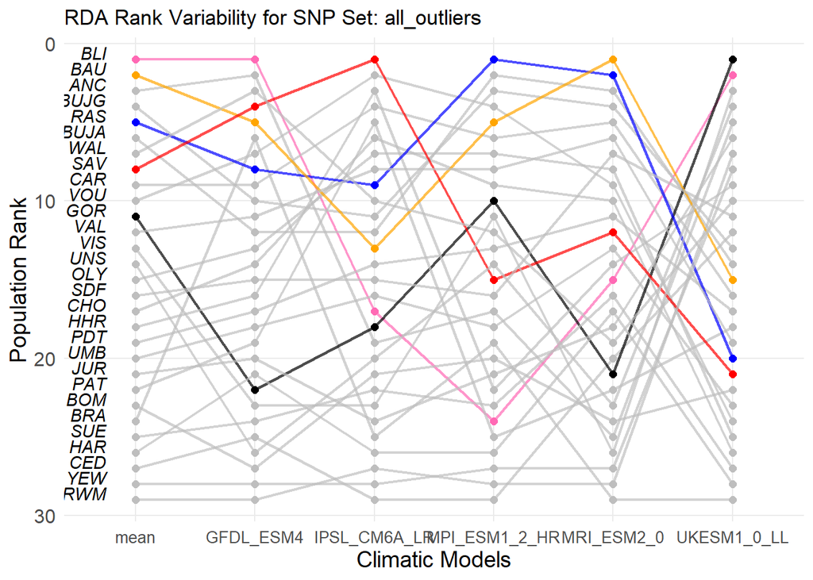

```r
list_models_clim<- c("mean","GFDL_ESM4","IPSL_CM6A_LR","MPI_ESM1_2_HR","MRI_ESM2_0","UKESM1_0_LL")

# List of SNP sets
list_sets <- c("all","random","random_same_AF","LC","MC","CG","random_AF_V2","all_outliers")

# Initialize an empty list to store data for all SNP sets
plot_data <- list()

# Load the RColorBrewer package for dynamic color palettes
library(RColorBrewer)


color_palette <- c("#FF69B4","red","blue","orange","black","green")

# Initialize a vector to keep track of top populations across all GCMs

meta_data_pop$pop_abbrev <- c("VIS","BAU","SDF","PAT","CHO","VOU","OLY","ANC","PDT","UMB","VAL","BRA","HAR","GOR","BOM","UNS","BUJA","BUJG","CAR","RAS","SUE","SAV","BLI","HHR","JUR","WAL","CED","RWM","YEW")

meta_data_f <- meta_data_pop[order(meta_data_pop$Population),]
# Loop over each SNP set
for (x in 1:length(list_sets)) {

  set <- list_sets[x]
  # Initialize an empty data frame for all models in the current SNP set
  ranks_df <- data.frame()

  all_top_populations <- character(0)

  # Loop over each climatic model
  for (i in 1:length(list_models_clim)) {

    model <- list_models_clim[i]
    # Get the genomic offset data for the current SNP set and model
    GO_data <- get(paste0("GO_T_Adapcon_Gentree_RDA_", set, "_future_", model))
    colnames(GO_data) <- c("Population", "GO")

    GO_data_V2 <- merge(GO_data,meta_data_f[,c(1,2,7)],"Population")

    # Rank the populations by genomic offset (highest GO gets rank 1)
    GO_data_V2$Rank <- rank(-GO_data_V2$GO, ties.method = "first")

    # Add columns for the climatic model and SNP set
    GO_data_V2$Model <- model
    GO_data_V2$Set <- set

    # Append to ranks dataframe
    ranks_df <- rbind(ranks_df, GO_data_V2)

    # Find the top 1 population for the current model (highest GO = rank 1)
    top_1_population <- GO_data_V2 %>% top_n(1, GO) %>% pull(Population)

    # Add this top 1 population to the list of all top populations (avoid duplicates)
    all_top_populations <- unique(c(all_top_populations, top_1_population))
  }

  # Convert 'Model' and 'Set' to factors for plotting
  ranks_df$Model <- factor(ranks_df$Model, levels = list_models_clim)
  ranks_df$Set <- factor(ranks_df$Set, levels = list_sets)

  # Adjust the number of colors if there are more top populations than the current color palette
  num_top_populations <- length(all_top_populations)
  if (num_top_populations > length(color_palette)) {
    color_palette <- colorRampPalette(brewer.pal(9, "Set1"))(num_top_populations)  # Use a different palette if needed
  }

  # Assign a unique color to each of the top populations (those ranked 1 in any model)
  population_colors <- setNames(color_palette[1:num_top_populations], all_top_populations)

  # Create a new column to store color assignments (highlight only rank 1 populations for each GCM)
  ranks_df$Highlight <- ifelse(ranks_df$Population %in% all_top_populations, ranks_df$Population, "Other")

  # Map colors for top populations and grey for the rest
  ranks_df$Color <- ifelse(ranks_df$Highlight == "Other", "grey", population_colors[ranks_df$Highlight])

  # Store the data frame for this SNP set in the plot_data list
  plot_data[[set]] <- ranks_df

# Modify the plot generation code
p <- ggplot(ranks_df, aes(x = Model, y = Rank, group = Population)) +
  geom_line(aes(color = Highlight), alpha = 0.7, size = 0.8) +  # Color only top populations
  geom_point(aes(color = Highlight), size = 2) +  # Color only top populations
  geom_text(
    data = ranks_df %>% filter(Model == list_models_clim[1]),  # Label only in first column
    aes(label = meta_data_f$pop_abbrev[match(Population, meta_data_f$Population)]),
    hjust = 1,  # Align to the left
    vjust = 0,
    size = 3.8,   # Increase text size
    nudge_x = -0.25,
    fontface= "italic"
    # Move text further left
  ) +
  scale_y_reverse() +  # Reverse rank (1 = top)
  scale_color_manual(values = c(population_colors, "Other" = "grey")) +  # Keep top populations colored, others grey
  labs(
    title = paste("RDA Rank Variability for SNP Set:", set),
    x = "Climatic Models", y = "Population Rank"
  ) +
  theme_minimal() +
  theme(
    legend.position = "none",
    panel.grid.minor = element_blank(),
    strip.text = element_text(size = 10, face = "bold"),
    legend.title = element_text(size = 10),
              axis.title.x = element_text(size = 14),
              axis.title.y = element_text(size = 14),
              axis.text.x = element_text(size = 10),
              axis.text.y = element_text(size = 12),
              legend.text = element_text(size = 12)
  )

print(p)  # Display plot for this SNP set
  #save
     pdf(paste0("C:/Users/tfrancisco/Documents/Thesis/Results/species/taxus/Genomic_offset/RDA/figures/comparison/GCMs/GO_rank_comparison_",set,".pdf"));print(p);dev.off()

}
```

We are going to use the mean of the GO predictions from the five GCMs as the future GO.

### 6.1.4 Graphical visualization

We can plot the genomic offset values for each population. As before, we can use the ‘cut_interval’ function to rescale the values so that they align with the colour scale used for other genomic offsets, such as GF.

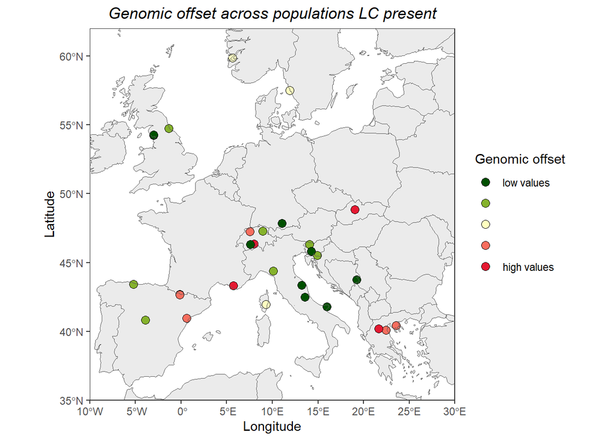

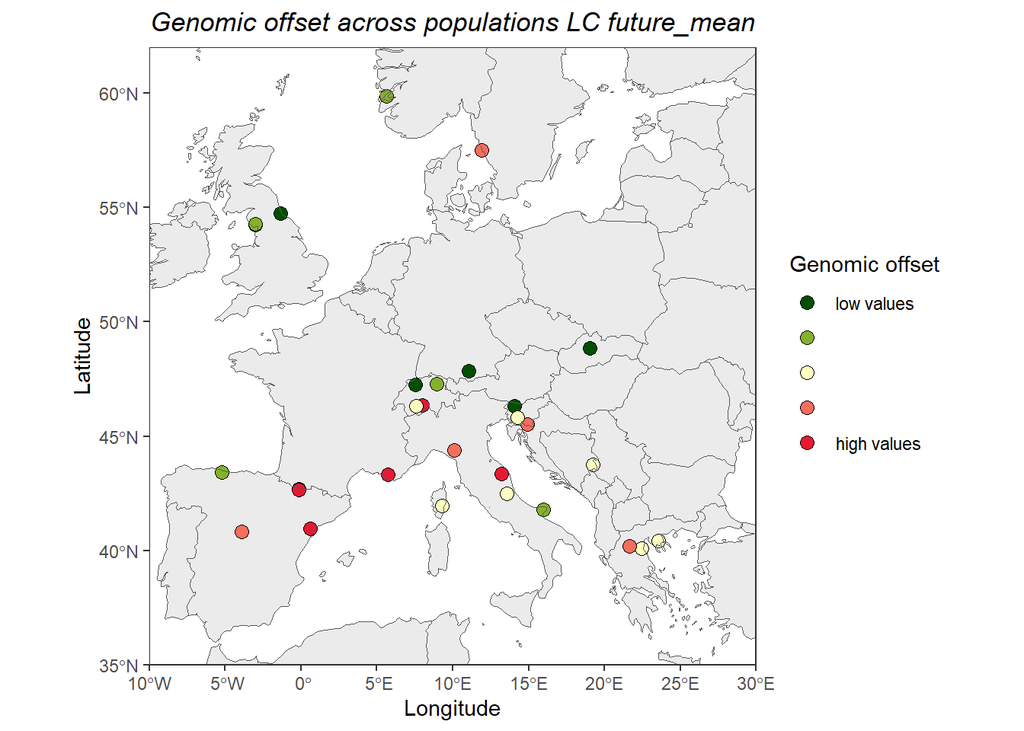

```r
list_period <- c("present","future")
list_set <- c("all","random","random_same_AF","LC","MC","CG","random_AF_V2","all_outliers")

for(i in 1:length(list_period)){

  period <- list_period[i]

  for(x in 1: length(list_set)){

    set <- list_set[x]

    if(period == "future"){

      for (j in 1:length(list_models_clim)) {

    model_clim <- list_models_clim[j]

    name_file <- paste0(set,"_",period,"_",model_clim)
    GO_df <- get(paste0("GO_T_Adapcon_Gentree_RDA_",name_file))

     #first, we need to add the coordinates
Genomic_offset_coord <- merge(GO_df,meta_data_pop_order[,c(2,4,5)],"Population")

#transform longitude and latitude to numeric variables
Genomic_offset_coord <- Genomic_offset_coord %>% mutate(Longitude=as.numeric(Longitude),Latitude=as.numeric(Latitude))


colors <- c("#005000","#85B22C","#FFFFBF","#F76D5E","#E51932")
#background map
admin <- ne_countries(scale = "medium", returnclass = "sf")

plot <- ggplot(data = Genomic_offset_coord) +
  geom_sf(data = admin, fill = gray(0.92), size = 0) +
  geom_point(aes(x = Longitude, y = Latitude, fill = cut_interval(Genomic_offset_coord[,2], n = 5)), shape = 21,size=3, color = "black") +
  scale_fill_manual(
    values = colors,
    labels = c("low values","","","","high values"),
    drop = FALSE,na.translate = FALSE)+  # Ensure all levels are shown in the legend
  geom_sf(data = admin, fill = NA, size = 0.1) +
  coord_sf(xlim = c(-10, 30), ylim = c(35, 62), expand = FALSE) +
  xlab("Longitude") + ylab("Latitude") +
  guides(fill = guide_legend(title = "Genomic offset")) +
  ggtitle(paste0("Genomic offset across populations ",set," ",period,"_",model_clim)) +
  theme_bw(base_size = 11) +
  theme(legend.position="right", panel.grid = element_blank(), strip.text = element_text(size=11),plot.title = element_text(hjust = 0.5,color = "Black",face="italic"))

print(plot)

#save
     pdf(paste0("C:/Users/tfrancisco/Documents/Thesis/Results/species/taxus/Genomic_offset/RDA/figures/GO/GCMs_separate_and_mean/future/GO_RDA_standard_across_populations_",set,"_",period,"_",model_clim,".pdf"));print(plot);dev.off()
      }

} else {

         name_file <- paste0(set,"_",period)
    GO_df <- get(paste0("GO_T_Adapcon_Gentree_RDA_",name_file))

     #first, we need to add the coordinates
Genomic_offset_coord <- merge(GO_df,meta_data_pop_order[,c(2,4,5)],"Population")

#transform longitude and latitude to numeric variables
Genomic_offset_coord <- Genomic_offset_coord %>% mutate(Longitude=as.numeric(Longitude),Latitude=as.numeric(Latitude))


colors <- c("#005000","#85B22C","#FFFFBF","#F76D5E","#E51932")
#background map
admin <- ne_countries(scale = "medium", returnclass = "sf")

plot <- ggplot(data = Genomic_offset_coord) +
  geom_sf(data = admin, fill = gray(0.92), size = 0) +
  geom_point(aes(x = Longitude, y = Latitude, fill = cut_interval(Genomic_offset_coord[,2], n = 5)), shape = 21,size=3, color = "black") +
  scale_fill_manual(
    values = colors,
    labels = c("low values","","","","high values"),
    drop = FALSE,na.translate = FALSE)+  # Ensure all levels are shown in the legend
  geom_sf(data = admin, fill = NA, size = 0.1) +
  coord_sf(xlim = c(-10, 30), ylim = c(35, 62), expand = FALSE) +
  xlab("Longitude") + ylab("Latitude") +
  guides(fill = guide_legend(title = "Genomic offset")) +
  ggtitle(paste0("Genomic offset across populations ",set," ",period)) +
  theme_bw(base_size = 11) +
  theme(legend.position="right", panel.grid = element_blank(), strip.text = element_text(size=11),plot.title = element_text(hjust = 0.5,color = "Black",face="italic"))

print(plot)

#save
     pdf(paste0("C:/Users/tfrancisco/Documents/Thesis/Results/species/taxus/Genomic_offset/RDA/figures/GO/GCMs_separate_and_mean/present/GO_RDA_standard_across_populations_",set,"_",period,".pdf"));print(plot);dev.off()

    }
  }
}
```

### 6.1.5 Correlation GO values across models

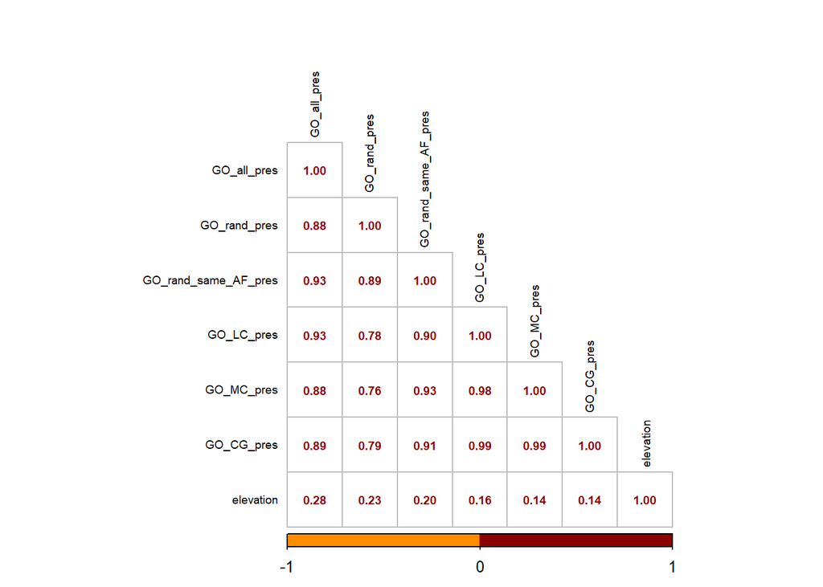

```r
#df
df_tot_GO_predictions_present <- data.frame(Population=GO_T_Adapcon_Gentree_RDA_random_present[,1],GO_all_pres=GO_T_Adapcon_Gentree_RDA_all_present[,2],GO_rand_pres=GO_T_Adapcon_Gentree_RDA_random_present[,2],GO_rand_same_AF_pres=GO_T_Adapcon_Gentree_RDA_random_same_AF_present[,2],GO_LC_pres=GO_T_Adapcon_Gentree_RDA_LC_present[,2],GO_MC_pres=GO_T_Adapcon_Gentree_RDA_MC_present[,2],GO_CG_pres=GO_T_Adapcon_Gentree_RDA_CG_present[,2],elevation=as.numeric(meta_data_pop_order$Elevation.DEM_90m.))

correlation_present <- cor(df_tot_GO_predictions_present[,-1])
corrplot(correlation_present, method = "number", addrect = 2, col = c("darkorange","darkred"), type = "lower", tl.col = "black", tl.cex = 0.6, number.cex = 0.6)
```

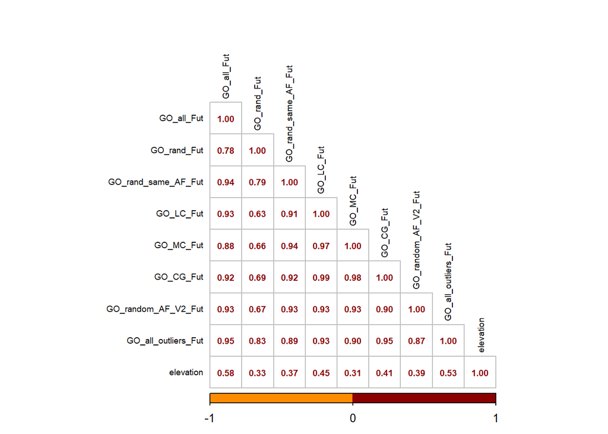

```r
df_tot_GO_predictions_future <- data.frame(Population=GO_T_Adapcon_Gentree_RDA_random_present[,1],GO_all_Fut=GO_T_Adapcon_Gentree_RDA_all_future_mean[,2],GO_rand_Fut=GO_T_Adapcon_Gentree_RDA_random_future_mean[,2],GO_rand_same_AF_Fut=GO_T_Adapcon_Gentree_RDA_random_same_AF_future_mean[,2],GO_LC_Fut=GO_T_Adapcon_Gentree_RDA_LC_future_mean[,2],GO_MC_Fut=GO_T_Adapcon_Gentree_RDA_MC_future_mean[,2],GO_CG_Fut=GO_T_Adapcon_Gentree_RDA_CG_future_mean[,2],GO_random_AF_V2_Fut=GO_T_Adapcon_Gentree_RDA_random_AF_V2_future_mean[,2],GO_all_outliers_Fut=GO_T_Adapcon_Gentree_RDA_all_outliers_future_mean[,2],elevation=as.numeric(meta_data_pop_order$Elevation.DEM_90m.))

correlation_future <- cor(df_tot_GO_predictions_future[,-1])
corrplot(correlation_future, method = "number", addrect = 2, col = c("darkorange","darkred"), type = "lower", tl.col = "black", tl.cex = 0.6, number.cex = 0.6)
```

```r
pdf("C:/Users/tfrancisco/Documents/Thesis/Results/species/taxus/Genomic_offset/RDA/figures/comparison/correlation_GO_present_values_RDA_T_set_period.pdf");corrplot(correlation_present, method = "number", addrect = 2, col = c("darkorange","darkred"), type = "lower", tl.col = "black", tl.cex = 0.6, number.cex = 0.6);dev.off()
```

```r
pdf("C:/Users/tfrancisco/Documents/Thesis/Results/species/taxus/Genomic_offset/RDA/figures/comparison/correlation_GO_future_values_RDA_T_set_period.pdf");corrplot(correlation_future, method = "number", addrect = 2, col = c("darkorange","darkred"), type = "lower", tl.col = "black", tl.cex = 0.6, number.cex = 0.6);dev.off()
```